# KFNFH Hatchery Data Objects

Exploration, QC checks, object descriptions and a draft data dictionary

# Purpose

The hatchery data objects of the package are **built in `data-raw/processing-scripts/process-hatchery-data.R`** and saved to `data/`. This document does not build anything: it loads the saved objects and explores them (a `glimpse()` and summaries of each), runs QC checks and plots on each one, describes each object, and holds a draft data dictionary.

**Where values come from.** Every value is taken from the annual reports (PDF text and tables) or the hatchery Excel workbooks. The mortality events are written in the script from the report text, and each event gives the report and page it comes from (`citation`).

**How the objects are built.** `process-hatchery-data.R` has these sections:

| Part of the script | What it does |
| --- | --- |
| PARSE PDF FILES, PROCESS TABLES | Report tables of each year (FY2021-FY2025, cached in `data-raw/pdf-tables/`) into per-year objects; intermediate objects `hatchery_release_2021_2024`, `adult_collection_2023_2024`, `pond_growout_repor… |
| 2. INPUTS FROM THE EXCEL WORKBOOKS AND THE REPORTS | Reads the workbooks and report text/tables: mortality spreadsheets, production harvest, spawning crosses, broodstock, fish movements and cohort age, collections and releases, capacity, and the mortali… |
| 3. FINAL OBJECTS | Merges the FY2021-2024 tables with FY2025 and the workbook inputs and saves the objects: collection and release history, pond grow-out, incubation and hatch, adult collection, hatchery release, net pe… |

# Assumptions and decisions

Every number in the objects comes from the annual reports or the hatchery workbooks. The items below are the places where a rule, a reading of the text, or a choice between sources decides a value. They were made while building the objects, and each one should be confirmed or changed.

| Area | What was assumed or decided |
| --- | --- |
| Mortality events E01-E28: descriptions | Each event is written from the FY2021-2024 report text, checked against the report pages named in `citation`. Wording keeps the report’s hedges (“suspected”, “likely”, “may have”) and leaves out detai… |
| Mortality events: losses typed from the text | E03 and E04 are 100% (“all perished”, “total losses within days of hatch”). E26 and E27 are 0%: the report says no sucker mortality was observed (it also gives 96% harvest survival for the Gerber pens… |
| Mortality events: severity tier | Over 70% is Catastrophic, 30-70% Major, 10-30% Moderate, under 10% Minor; an event that is not a mortality event is “Near-miss” if its loss is 0 and “Non-mortality” otherwise; an event with no percent… |
| Mortality events: fish lost (`n_mortality`) | Filled for E01, E11 (200, the report’s minimum), E12 and E16 (752) among E01-E28 (where the reports give the fish lost); counts that could be computed for others (for example E08, E17, E19) are left `… |
| FY2025 events E29-E37 | The category, `mortality_event` and `confidence` labels and the wording of the description columns are mine, written from the FY2025 report. **E29:** the loss is the fish at the start minus (harvested… |
| Pond grow-out | A completed cycle listed in two reports is kept once (the later report’s row, 44 cycles); a cycle reported in progress is replaced by its completed record; `fiscal_year` is the year of the report that… |
| Fish movements | The “Stocked To” cells are free text, read by rules for each format. A destination with no number has `n_fish` = `NA`; a date with no year has `move_date` = `NA` (the text stays in `date_text`). “Net … |
| Cohort age | The age class of a cohort at any stay is built by one rule for every object: net pens = operation year minus capture year; ponds, releases and monthly mortality = calendar year of the date minus the y… |
| Capacity | The pond counts and sizes are typed from report sentences, and each sentence is checked against the report text. FY2024 is set to 22 ponds because the four A-series ponds were demolished early in the … |
| Rounding | `total_eggs` is rounded to whole numbers, `hatch_percent` to one decimal (and captive `eggs_per_mL` to two), as in Excel, so FY2025 incubation values differ slightly from the raw workbook values (for … |
| Incubation and adult collection | FY2024 `family_groups` is the number of males listed (the table has no such value). Short PIT tags (4-5 characters) are expanded to the full tag when exactly one tag in the FY2025 workbook or report t… |
| Collection and release history | `larvae_collected` is taken from Table 7 (30,150 for FY2024) rather than Table 1 (30,142); `total_released` is the sum of the four release columns; `broodstock_on_station` is the number parsed from “a… |
| Early rearing | `restock` is set from the word “Restock” in the culture-unit name; `date` is the first date when a row lists two days. |
| QC checks | The tolerances (for example 5% for eggs, 2 points for survival) and the plausible ranges (for example fork length 300-1000 mm) were chosen for this document. |

# Inputs used for the checks

The FY2025 Production Harvest workbook is read here for two cross-checks (pond grow-out, and the September 2025 harvest). One row per pond cycle, sheets `FALL 2024`, `Spring 2025` and `Fall 2025`:

```r
ph_path <- here::here("data-raw/hatchery-resources/FY2025 Supporting Excel Tables/FY2025 Production Harvest Data Sheet_20251107.xlsx")

extract_col <- function(raw, pattern) {
  matched <- names(raw)[str_detect(str_squish(names(raw)), regex(pattern, ignore_case = TRUE))]
  if (length(matched) == 0) return(rep(NA_character_, nrow(raw)))
  if (length(matched) == 1) return(raw[[matched]])
  exec(coalesce, !!!as.list(raw[matched]))
}
excel_date <- function(x) as.Date(suppressWarnings(as.numeric(x)), origin = "1899-12-30")

production_harvest_fy2025 <- map2(c("FALL 2024", "Spring 2025", "Fall 2025"), c("Fall 2024", "Spring 2025", "Fall 2025"), \(sheet, season) {
  raw <- readxl::read_excel(ph_path, sheet = sheet, col_types = "text")
  tibble(pond = extract_col(raw, "^Pond$"),
         stocked_date = excel_date(extract_col(raw, "^Stocked? Date$")),
         start_number = suppressWarnings(as.numeric(extract_col(raw, "^Start #$"))),
         harvest_date = excel_date(extract_col(raw, "^Harvest Date$")),
         end_number = suppressWarnings(as.numeric(extract_col(raw, "^End # Live$|^End #$"))),
         survival_percent = suppressWarnings(as.numeric(extract_col(raw, "^Survival$")))) |>
    filter(!is.na(pond), pond != "Pond") |>
    mutate(season = season, pond = str_to_upper(pond),
           # some seasons record survival as a fraction (0-1)
           survival_percent = if (!all(is.na(survival_percent)) && max(survival_percent, na.rm = TRUE) <= 1) survival_percent * 100 else survival_percent)
}) |> list_rbind()
```

# Fish movements and cohort age

These two objects answer “how old are the fish as they move through the system, by pond and net pen”.

**`KFNFH_fish_movements`** splits the free-text “Stocked To” cell of the Production Harvest workbooks (and the disposition column of the FY2021 report tables) into one row per destination. The cell formats change from sheet to sheet (`P10/454 on 3/9/25, P11/490 on 3/11/25`, `P9-50 / HENZEL-417`, `Stocked 325 to A3 / Stocked 547 to Henzel on 10/21/2022`), so each is read by a rule and every row keeps the whole cell (`source_text`) and its sheet and row (`source`). A cell with no destination gives no row. A destination is a pond code, a net pen, or another named place (`to_type`).

```r
glimpse(KFNFH_fish_movements, width = 100)
```

```
## Rows: 342
## Columns: 15
## $ hatchery_name      <chr> "KFNFH", "KFNFH", "KFNFH", "KFNFH", "KFNFH", "KFNFH", "KFNFH", "KFNFH",…
## $ fiscal_year        <dbl> 2020, 2020, 2020, 2020, 2020, 2020, 2020, 2020, 2020, 2020, 2020, 2020,…
## $ from_facility      <chr> "A3", "A3", "P11", "P11", "P12", "P12", "P13", "P13", "P14", "P14", "P1…
## $ lot                <chr> "2018", "2018", "2019", "2019", "2019", "2019", "2019", "2019", "2019",…
## $ cycle_stock_date   <date> NA, NA, NA, NA, NA, NA, NA, NA, NA, NA, NA, NA, NA, NA, NA, NA, NA, NA…
## $ cycle_harvest_date <date> 2020-09-01, 2020-09-01, 2020-09-28, 2020-09-28, 2020-09-28, 2020-09-28…
## $ to_label           <chr> "Stocked (destination not named)", "P8", "Stocked (destination not name…
## $ to_facility        <chr> NA, "P8", NA, "A3", NA, "A3", NA, "A3", NA, "A3", NA, "P9", "A3", NA, "…
## $ to_type            <chr> "stocked, destination not named", "pond", "stocked, destination not nam…
## $ n_fish             <dbl> 2790, 262, 371, 179, 121, 398, 681, 162, 286, 243, 604, 150, 47, 187, 2…
## $ move_date          <date> NA, NA, NA, NA, NA, NA, NA, NA, NA, NA, NA, NA, NA, NA, NA, NA, NA, NA…
## $ date_text          <chr> NA, NA, NA, NA, NA, NA, NA, NA, NA, NA, NA, NA, NA, NA, NA, NA, NA, NA,…
## $ note               <chr> NA, "Broodstock (2018 Lot)", NA, "Short Holdovers", NA, "Short Holdover…
## $ source             <chr> "FY2021 Table 3", "FY2021 Table 3", "FY2021 Table 3", "FY2021 Table 3",…
## $ source_text        <chr> "2790 Stocked; 262 Broodstock (2018 Lot) in Pond 8", "2790 Stocked; 262…
```

```r
KFNFH_fish_movements |> count(to_type, name = "rows")
```

| to_type | rows |
| --- | --- |
| net pen | 14 |
| other site | 60 |
| pond | 242 |
| retained at the hatchery | 4 |
| stocked, destination not named | 22 |

**`KFNFH_cohort_age`** stacks the pond cycles, net pen groups and releases and gives each its cohort and the age class at the start and end of the stay, with one rule for the age (calendar year of the date minus the year in the lot name or capture year, 4 = 4 or older; the same for every lot, including East Side Springs lots, **an assumption**). Filtering one `cohort` gives its stays in date order:

```r
glimpse(KFNFH_cohort_age, width = 100)
```

```
## Rows: 559
## Columns: 13
## $ hatchery_name <chr> "KFNFH", "KFNFH", "KFNFH", "KFNFH", "KFNFH", "KFNFH", "KFNFH", "KFNFH", "KFN…
## $ cohort        <chr> "2017", "2017", "2017", "2017", "2017", "2017", "2017", "2017", "2017", "201…
## $ cohort_year   <dbl> 2017, 2017, 2017, 2017, 2017, 2017, 2017, 2017, 2017, 2017, 2017, 2017, 2018…
## $ stage         <chr> "pond", "pond", "pond", "pond", "pond", "pond", "pond", "pond", "pond", "pon…
## $ facility      <chr> "P0", "P1", "P0", "P0", "P0", "P8", "P7", "P7", "P8", "P8", "P19", "UKLS", "…
## $ fiscal_year   <dbl> 2022, 2022, 2022, 2023, 2023, 2024, 2024, 2025, 2025, 2025, 2021, 2019, 2022…
## $ start_date    <date> 2021-05-10, 2021-05-11, 2022-03-02, 2022-09-19, 2023-03-14, 2023-05-22, 202…
## $ end_date      <date> 2022-02-28, 2021-11-09, 2022-09-19, 2023-03-13, 2023-05-22, 2023-11-27, 202…
## $ age_at_start  <chr> "4", "4", "4", "4", "4", "4", "4", "4", "4", "4", NA, "2", "2", "3", "4", "4…
## $ age_at_end    <chr> "4", "4", "4", "4", "4", "4", "4", "4", "4", "4", "4", "2", "3", "4", "4", "…
## $ start_number  <dbl> 91, 100, 90, 87, 86, 84, 85, 53, 32, 80, 25, 480, 262, 254, 251, 232, 103, 1…
## $ end_number    <dbl> 90, 91, 87, 87, 86, 85, 85, 49, 31, 71, 0, 10, 255, 251, 232, 220, 89, 86, 7…
## $ source        <chr> NA, "FY2022 Table 2", "FY2023 Table 5", "FY2023 Table 6", "FY2023 Table 7", …
```

```r
KFNFH_cohort_age |> count(stage, name = "rows")
```

| stage | rows |
| --- | --- |
| net pen | 19 |
| pond | 359 |
| release | 181 |

Check of the parsing: the fish moved out of a cycle should add up to the fish alive at harvest (`end_number`), for the workbook cycles where every destination has a number.

```r
cycle_moved <- KFNFH_fish_movements |>
  filter(str_detect(source, "xlsx"), to_type != "retained at the hatchery") |>
  group_by(source, from_facility, cycle_stock_date, cycle_harvest_date) |>
  summarise(moved = sum(n_fish, na.rm = TRUE), all_counted = !any(is.na(n_fish)), .groups = "drop") |>
  inner_join(KFNFH_pond_growout |> select(pond, pond_stock_date, harvest_date, end_number),
             by = c("from_facility" = "pond", "cycle_stock_date" = "pond_stock_date", "cycle_harvest_date" = "harvest_date"),
             relationship = "many-to-many") |>
  filter(all_counted, moved > 0, end_number > 0) |>
  mutate(ratio = moved / end_number)
tibble(workbook_cycles_with_destination_counts = nrow(cycle_moved),
       moved_within_10_percent_of_end_number = sum(abs(cycle_moved$ratio - 1) <= 0.1))
```

| workbook_cycles_with_destination_counts | moved_within_10_percent_of_end_number |
| --- | --- |
| 74 | 68 |

```r
cycle_moved |>
  filter(abs(ratio - 1) > 0.1) |>
  transmute(source = str_remove(source, "^.*sheet "), from_facility, cycle_harvest_date, moved, end_number, ratio = round(ratio, 2))
```

| source | from_facility | cycle_harvest_date | moved | end_number | ratio |
| --- | --- | --- | --- | --- | --- |
| FALL 2024, row 13 | P10 | 2024-10-23 | 1327 | 1495 | 0.89 |
| FALL 2024, row 22 | P19 | 2024-10-22 | 289 | 325 | 0.89 |
| Fall 2025, row 27 | C1 | 2025-09-11 | 8527 | 12697 | 0.67 |
| Fall 2025, row 28 | C2 | 2025-09-10 | 5247 | 12131 | 0.43 |
| FALL 2023, row 27 | A3 | 2023-10-30 | 3381 | 2986 | 1.13 |
| SPRING 2024, row 3 | P0 | 2024-02-27 | 1771 | 805 | 2.20 |

# Collection and release history

`KFNFH_historical_collection_release` is built from Table 1 and Table 7 of the FY2025 report, which repeat the full history (FY2016-2025) with updated numbers; the broodstock columns come from the report text.

```r
glimpse(KFNFH_historical_collection_release, width = 100)
```

```
## Rows: 10
## Columns: 18
## $ hatchery_name             <chr> "KFNFH", "KFNFH", "KFNFH", "KFNFH", "KFNFH", "KFNFH", "KFNFH", "…
## $ fiscal_year               <dbl> 2016, 2017, 2018, 2019, 2020, 2021, 2022, 2023, 2024, 2025
## $ larvae_collected          <dbl> 4134, 8730, 9544, 24426, 40603, 106710, 51929, 6036, 30150, 70049
## $ sarp_release              <dbl> NA, NA, 2355, 4497, 11774, 13394, 12768, 17399, 12433, 2623
## $ sarp_tl_mm                <dbl> NA, NA, 147, 189, 223, 208, 193, 194, 221, 223
## $ fingerling_release        <dbl> NA, NA, NA, NA, NA, NA, 4655, 15604, NA, NA
## $ fingerling_tl_mm          <dbl> NA, NA, NA, NA, NA, NA, 118, 89, NA, NA
## $ fry_release               <dbl> NA, NA, NA, NA, NA, NA, 19993, 14973, 4632, 23719
## $ fry_tl_mm                 <dbl> NA, NA, NA, NA, NA, NA, 10, 10, 10, 10
## $ salvage_release           <dbl> NA, NA, 784, 1586, 1928, 1689, NA, 436, 801, 112
## $ salvage_sl_mm             <dbl> NA, NA, 102, 103, 94, 143, NA, NA, NA, NA
## $ salvage_tl_mm             <dbl> NA, NA, NA, NA, NA, NA, NA, 129, 126, 144
## $ primary_collection_method <chr> "Drift Net (Passive Method)", "Drift Net (Passive Method)", "Dri…
## $ total_released            <dbl> 0, 0, 3139, 6083, 13702, 15083, 37416, 48412, 17866, 26454
## $ broodstock_on_station_raw <chr> NA, NA, NA, NA, NA, "over 650", NA, "approximately 1,369", "appr…
## $ broodstock_cohort_years   <chr> NA, NA, NA, NA, NA, "CY2017-2019", NA, "CY2017-2022", "CY2017-20…
## $ new_broodstock_reported   <dbl> NA, NA, NA, NA, NA, 300, NA, NA, NA, NA
## $ broodstock_on_station     <dbl> NA, NA, NA, NA, NA, 650, NA, 1369, 1341, 1119
```

FY2024 `larvae_collected` is **30,142** in FY2025 Table 1, but **30,150** in the FY2024 report (Tables 1 and 4, and the narrative), in FY2025 Table 7 of the FY2025 report itself, and in the hatchery’s own workbook (the cumulative “Total Collected To Date” in `2024 Larval Collection and Early Rearing Summary Data.xlsx` ends at 30,150). Three sources agree on 30,150, so **the object uses the Table 7 value (30,150) for all years** (it equals Table 1 in every other year). The same workbooks also confirm FY2023 (6,036) and FY2025 (70,049).

# Pond grow-out

`KFNFH_pond_growout` combines the pond tables of the FY2021-FY2025 reports. The Production Harvest Data Sheet workbooks describe the same pond cycles; for FY2021-2024 their rows match the report rows on pond and harvest date (start numbers are identical; end numbers and survival agree for about 95% of rows), so they are not appended as a second copy. The script:

1. keeps the report tables as the primary source (they have the full set of columns, including weights);
2. adds FY2025 from the FY2025 report pond tables (Tables 10-12) so FY2025 has the same columns as earlier years;
3. validates the FY2025 rows against the workbook, and would append (flagged `source = "production_harvest_workbook"`) any workbook row that is not in the report tables (there are none);
4. replaces a cycle reported as still in progress (no harvest date) in an earlier report with the later, completed record of the same pond and stocking date;
5. removes a completed cycle that is listed in two consecutive reports (44 cycles: 24 in both FY2023 Table 7 and FY2024 Table 6, and 20 in both the FY2022 tables and FY2023 Table 5), keeping the later report’s row;
6. calculates `age_class` for each cycle from its own lot name and the calendar year it was harvested (`NA` for a cycle in progress).

```r
glimpse(KFNFH_pond_growout, width = 100)
```

```
## Rows: 359
## Columns: 37
## $ hatchery_name            <chr> "KFNFH", "KFNFH", "KFNFH", "KFNFH", "KFNFH", "KFNFH", "KFNFH", "K…
## $ fiscal_year              <dbl> 2021, 2021, 2021, 2021, 2021, 2021, 2021, 2021, 2021, 2021, 2021,…
## $ inventory_source         <chr> "FY2021 Table 4", "FY2021 Table 3", "FY2021 Table 3", "FY2021 Tab…
## $ life_history             <chr> "adfluvial", "adfluvial", "adfluvial", "adfluvial", "adfluvial", …
## $ source                   <chr> "annual_report_table", "annual_report_table", "annual_report_tabl…
## $ pond                     <chr> "A1", "A2", "A3", "A3", "A4", "B1", "B10", "B11", "B12", "B13", "…
## $ lot                      <chr> "2020", "2019", "2018", "2019", "2020", "2020", "2020", "2020", "…
## $ pond_stock_date          <date> NA, NA, NA, NA, NA, NA, NA, NA, NA, NA, NA, NA, NA, NA, NA, NA, …
## $ harvest_date             <date> 2021-03-30, 2020-10-20, 2020-09-01, 2021-04-26, 2021-04-06, 2021…
## $ start_number             <dbl> 6995, 2640, 2804, 5120, 6980, 529, 532, 531, 533, 533, 533, 97, 5…
## $ start_g_fish             <dbl> NA, NA, NA, NA, NA, NA, NA, NA, NA, NA, NA, NA, NA, NA, NA, NA, N…
## $ start_wt_g               <dbl> NA, NA, NA, NA, NA, NA, NA, NA, NA, NA, NA, NA, NA, NA, NA, NA, N…
## $ start_wt_lb              <dbl> NA, NA, NA, NA, NA, NA, NA, NA, NA, NA, NA, NA, NA, NA, NA, NA, N…
```

[output cut: 24 more lines]

```r
KFNFH_pond_growout |> count(fiscal_year, source)
```

| fiscal_year | source | n |
| --- | --- | --- |
| 2021 | annual_report_table | 64 |
| 2022 | annual_report_table | 103 |
| 2023 | annual_report_table | 66 |
| 2024 | annual_report_table | 46 |
| 2025 | annual_report_table | 80 |

Validation of the completed FY2025 cycles against the Production Harvest workbook:

```r
key <- function(d, stock, pond = "pond") ifelse(is.na(d[[stock]]), NA, paste(d[[pond]], d[[stock]]))

pond_2025_report <- KFNFH_pond_growout |> filter(fiscal_year == 2025, source == "annual_report_table")

fy25_check <- pond_2025_report |>
  filter(!is.na(harvest_date)) |>
  mutate(k = key(pick(everything()), "pond_stock_date")) |>
  inner_join(production_harvest_fy2025 |> filter(!is.na(harvest_date)) |>
               mutate(k = key(pick(everything()), "stocked_date")) |>
               select(k, wb_start = start_number, wb_end = end_number, wb_survival = survival_percent),
             by = "k")

tibble(completed_report_rows_fy25 = sum(!is.na(pond_2025_report$harvest_date)),
       matched_to_workbook = nrow(fy25_check),
       start_number_equal = mean(fy25_check$start_number == fy25_check$wb_start, na.rm = TRUE),
       end_number_equal = mean(fy25_check$end_number == fy25_check$wb_end, na.rm = TRUE),
       end_number_minus_morts_equal = mean(fy25_check$end_number - fy25_check$harvest_mortality_number == fy25_check$wb_end, na.rm = TRUE),
       survival_within_0.5 = mean(abs(fy25_check$survival_percent - fy25_check$wb_survival) < 0.5, na.rm = TRUE))
```

| completed_report_rows_fy25 | matched_to_workbook | start_number_equal | end_number_equal | end_number_minus_morts_equal | survival_within_0.5 |
| --- | --- | --- | --- | --- | --- |
| 55 | 55 | 1 | 0.436 | 1 | 1 |

For the completed FY2025 cycles, start numbers are identical and survival agrees. The FY2025 report’s `End #` counts fish before harvest mortalities, while the workbook’s `End #` is the live count, so `end_number - harvest_mortality_number` equals the workbook value for every matched row.

Cycles with no age class are lots with no year in the name:

```r
KFNFH_pond_growout |>
  filter(is.na(age_class)) |>
  count(fiscal_year, pond) |>
  arrange(fiscal_year, pond)
```

first 25 of 40 rows

| fiscal_year | pond | n |
| --- | --- | --- |
| 2021 | B3 | 1 |
| 2022 | A1 | 1 |
| 2022 | A2 | 1 |
| 2022 | A4 | 1 |
| 2024 | A1 | 1 |
| 2024 | P10 | 1 |
| 2024 | P11 | 1 |
| 2024 | P13 | 1 |
| 2024 | P14 | 1 |
| 2024 | P15 | 1 |
| 2024 | P16 | 1 |
| 2024 | P17 | 1 |
| 2024 | P18 | 1 |
| 2024 | P19 | 1 |
| 2024 | P20 | 1 |
| 2025 | B1 | 1 |
| 2025 | B2 | 1 |
| 2025 | C3 | 1 |
| 2025 | C4 | 1 |
| 2025 | C5 | 1 |
| 2025 | C6 | 1 |
| 2025 | P0 | 1 |
| 2025 | P1 | 1 |
| 2025 | P10 | 1 |
| 2025 | P12 | 1 |

# Incubation and hatch results

`KFNFH_LRS_ESS_incubation_hatch` (the `_2024` suffix is dropped) holds the wild East Side Springs LRS spawning crosses of FY2024 (report Table 3) and FY2025 (the ESS metadata workbook, identical to report Table 3), with the family-group count and, for FY2025, the second fry count.

```r
glimpse(KFNFH_LRS_ESS_incubation_hatch, width = 100)
```

```
## Rows: 32
## Columns: 22
## $ hatchery_name        <chr> "KFNFH", "KFNFH", "KFNFH", "KFNFH", "KFNFH", "KFNFH", "KFNFH", "KFNFH…
## $ fiscal_year          <dbl> 2024, 2024, 2024, 2024, 2024, 2024, 2024, 2024, 2024, 2024, 2024, 202…
## $ program              <chr> "Wild ESS Spawning", "Wild ESS Spawning", "Wild ESS Spawning", "Wild …
## $ species              <chr> "LRS", "LRS", "LRS", "LRS", "LRS", "LRS", "LRS", "LRS", "LRS", "LRS",…
## $ spawning_date        <date> 2024-04-17, 2024-04-17, 2024-04-24, 2024-04-24, 2024-04-24, 2024-04-…
## $ female               <chr> "003D6B96AC", "003D6B96AC", "257C5DC4F7", "003D6D42B0", "003D6D42B9",…
## $ male_1               <chr> "257C5DBC9C", "257C5DBC9C", "003D6D42A2", "003D6B9717", "003C08883C",…
## $ male_2               <chr> "003D6D4420", "003D6D4420", "003C08DB3F", "003BC11270", "003BC11270",…
## $ male_3               <chr> "003D485428", "003D485428", "003D6B9717", "003D485524", "003D485512",…
## $ male_4               <chr> "003BBFCD43", "003BBFCD43", "003BC11270", "003D485512", "003C08DB3F",…
## $ male_5               <chr> NA, NA, NA, NA, NA, NA, NA, NA, NA, NA, NA, NA, NA, NA, NA, NA, NA, N…
## $ male_6               <chr> NA, NA, NA, NA, NA, NA, NA, NA, NA, NA, NA, NA, NA, NA, NA, NA, NA, N…
## $ family_groups        <dbl> 4, 4, 4, 4, 4, 4, 4, 4, 4, 4, 4, 4, 4, 2, 4, 2, 2, 2, 5, 4, 1, 3, 2, …
## $ incubator            <chr> "aquaria", "jars", "jars", "jars", "jars", "jars", "jars", "jars", "j…
## $ egg_volume_mL        <dbl> 28.16, 192.00, 170.00, 175.00, 295.00, 200.00, 125.00, 160.00, 65.00,…
## $ eggs_per_mL          <dbl> 42.60, 42.60, 34.33, 47.00, 35.00, 35.00, 30.33, 34.00, 42.00, 41.65,…
## $ total_eggs           <dbl> 1200, 8179, 5836, 8225, 10325, 7000, 3791, 5440, 2730, 6872, 6788, 13…
## $ total_fry            <dbl> 483, 5258, 4086, 2253, 11090, 3346, 517, 547, 2799, 6457, 3420, 13137…
## $ hatch_percent        <dbl> 40.3, 64.3, 70.0, 27.4, 107.4, 47.8, 13.6, 10.1, 102.5, 94.0, 50.4, 9…
## $ hatch_date           <date> 2024-04-24, 2024-04-22, 2024-05-02, 2024-05-02, 2024-05-02, 2024-05-…
## $ second_fry_count     <dbl> NA, NA, NA, NA, NA, NA, NA, NA, NA, NA, NA, NA, NA, NA, 97, 158, 5629…
## $ second_hatch_percent <dbl> NA, NA, NA, NA, NA, NA, NA, NA, NA, NA, NA, NA, NA, NA, 3.0, 5.8, 63.…
```

```r
KFNFH_LRS_ESS_incubation_hatch |> count(fiscal_year)
```

| fiscal_year | n |
| --- | --- |
| 2024 | 14 |
| 2025 | 18 |

# Adult collection and hatchery release, FY2025

The FY2025 report gives FY2025 versions of both tables, which are added to the FY2023-2024 data.

```r
glimpse(KFNFH_LRS_ESS_adult_collection, width = 100)
```

```
## Rows: 141
## Columns: 15
## $ hatchery_name          <chr> "KFNFH", "KFNFH", "KFNFH", "KFNFH", "KFNFH", "KFNFH", "KFNFH", "KFN…
## $ fiscal_year            <dbl> 2024, 2024, 2024, 2024, 2024, 2024, 2024, 2024, 2024, 2024, 2024, 2…
## $ date                   <date> 2024-04-17, 2024-04-17, 2024-04-17, 2024-04-17, 2024-04-17, 2024-0…
## $ fin_clip_id_number     <chr> "3960-049", "3960-050", "3960-051", "3960-052", "3960-053", "3960-0…
## $ pit_tag_suffix         <chr> "257C5DBC9C", "003D6D4420", "003D485428", "003BBFCD43", "003D6B96AC…
## $ pit_tag_last_5         <chr> "DBC9C", "D4420", "85428", "FCD43", "B96AC", "DC4F7", "D42B0", "D42…
## $ sex                    <chr> "Male", "Male", "Male", "Male", "Female", "Female", "Female", "Fema…
## $ gamete_use             <chr> "Spawned", "Spawned", "Spawned", "Spawned", "Spawned", "Spawned", "…
## $ fl_mm                  <dbl> 690, 543, 538, 615, 787, 743, 727, 730, 762, 707, 727, 633, 685, 73…
## $ tl_mm                  <chr> "732", "584", "572", "661", "830", "784", "776", "772", "808", "749…
## $ spring_location        <chr> "CINDER", "SUCKER", "SUCKER", "SUCKER", "SUCKER", "CINDER", "CINDER…
## $ family_groups          <dbl> NA, NA, NA, NA, 4, 4, 4, 4, 4, 4, 4, NA, NA, NA, NA, NA, NA, NA, NA…
## $ fl_in                  <dbl> 27.16535, 21.37795, 21.18110, 24.21260, 30.98425, 29.25197, 28.6220…
## $ atfc_genetic_id        <chr> NA, NA, NA, NA, NA, NA, NA, NA, NA, NA, NA, NA, NA, NA, NA, NA, NA,…
## $ fry_collected_for_aftc <lgl> NA, NA, NA, NA, NA, NA, NA, NA, NA, NA, NA, NA, NA, NA, NA, NA, NA,…
```

```r
KFNFH_LRS_ESS_adult_collection |> count(fiscal_year, sex)
```

| fiscal_year | sex | n |
| --- | --- | --- |
| 2023 | Female | 10 |
| 2023 | Male | 17 |
| 2023 | NA | 2 |
| 2024 | Female | 13 |
| 2024 | Male | 30 |
| 2025 | Female | 23 |
| 2025 | Male | 46 |

```r
glimpse(KFNFH_hatchery_release, width = 100)
```

```
## Rows: 181
## Columns: 16
## $ hatchery_name       <chr> "KFNFH", "KFNFH", "KFNFH", "KFNFH", "KFNFH", "KFNFH", "KFNFH", "KFNFH"…
## $ fiscal_year         <dbl> 2025, 2025, 2025, 2025, 2025, 2025, 2025, 2025, 2025, 2025, 2025, 2025…
## $ dispo_date          <date> 2024-10-24, 2024-11-05, 2024-11-05, 2024-11-06, 2024-11-07, 2024-11-0…
## $ species             <chr> "ESS LRS", "LRS", "SNS", "SNS", "ESS LRS", "LRS", "SNS", "Unknown", "U…
## $ lot                 <chr> "2023", "Mixed", "Mixed", "2023", "2023", "Salvage", "Salvage", "Salva…
## $ number_fish         <dbl> 360, 46, 230, 765, 805, 4, 43, 50, 10, 5, 6043, 17676, 417, 5, 178, 23…
## $ weight_lb           <dbl> 60.62, 16.28, 114.25, 141.94, 183.49, 0.21, 4.98, 1.31, 0.43, 0.51, 0.…
## $ actual_tl_mm        <dbl> 202.00, 265.00, 226.00, 194.00, 218.00, 139.00, 171.00, 110.00, 121.00…
## $ number_per_lb       <dbl> 5.94, 2.82, 2.01, 5.39, 4.39, 19.12, 8.63, 38.28, 23.26, 9.80, 60430.0…
## $ projected_tl_inches <dbl> 8.12, 10.41, 11.08, 7.98, 8.99, 5.50, 6.82, 4.15, 4.90, 6.54, 0.36, 0.…
## $ projected_tl_mm     <dbl> 206, 264, 281, 203, 228, 140, 173, 105, 125, 166, 9, 9, 244, 656, 434,…
## $ from_ponds          <chr> "P16", "4-Mile Canal Net Pen", "4-Mile Canal Net Pen", "C2", "C5", "Fo…
## $ dispo_location      <chr> "Hanks Marsh Lakeside Boat Ramp", "4-Mile Canal Net Pen", "4-Mile Cana…
## $ fish_type           <chr> NA, NA, NA, NA, NA, NA, NA, NA, NA, NA, NA, NA, NA, NA, NA, NA, NA, NA…
## $ tl_inches           <dbl> NA, NA, NA, NA, NA, NA, NA, NA, NA, NA, NA, NA, NA, NA, NA, NA, NA, NA…
## $ tl_mm               <dbl> NA, NA, NA, NA, NA, NA, NA, NA, NA, NA, NA, NA, NA, NA, NA, NA, NA, NA…
```

```r
KFNFH_hatchery_release |> group_by(fiscal_year) |> summarise(rows = n(), fish = sum(number_fish, na.rm = TRUE))
```

| fiscal_year | rows | fish |
| --- | --- | --- |
| 2021 | 43 | 14643 |
| 2022 | 28 | 37416 |
| 2023 | 63 | 48377 |
| 2024 | 34 | 17866 |
| 2025 | 13 | 26454 |

The FY2025 report states 26,454 fish distributed or transferred (“All Spp.” overall total) and `FY25 Fish Distribution.xlsx` has the same table.

# Net pen survival

FY2025 Tables 13 and 14 repeat the full net pen history (identical to `nphistory.xlsx`). The new information is that no production fish were available in later years, which is recorded as explicit rows with a `note` so these are not mistaken for missing data.

```r
glimpse(KFNFH_pen_survival, width = 100)
```

```
## Rows: 23
## Columns: 11
## $ hatchery_name       <chr> "KFNFH", "KFNFH", "KFNFH", "KFNFH", "KFNFH", "KFNFH", "KFNFH", "KFNFH"…
## $ pen_type            <chr> "Gerber Net Pen", "Gerber Net Pen", "Gerber Net Pen", "Gerber Net Pen"…
## $ operation_year      <dbl> 2021, 2021, 2021, 2021, 2022, 2023, 2023, 2024, 2024, 2025, 2019, 2019…
## $ captured_year       <dbl> 2019, 2020, 2019, 2020, NA, 2021, 2021, 2022, 2022, NA, 2018, 2017, 20…
## $ pen_id              <chr> "GERE", "GERE", "GERW", "GERW", NA, "GERE", "GERW", "GERE", "GERW", NA…
## $ stock_tl_mm         <dbl> 235, 140, 230, 138, NA, 170, 171, 149, 148, NA, 160, 236, 224, 228, 13…
## $ number_stocked      <dbl> 100, 898, 150, 1331, NA, 1005, 1036, 648, 730, NA, 534, 480, 220, 100,…
## $ harvest_tl_mm       <dbl> 269, 174, 265, 173, NA, 225, 214, 205, 201, NA, 0, 263, 233, 0, 0, 280…
## $ number_harvested    <dbl> 97, 827, 146, 1105, NA, 454, 1000, 624, 693, NA, 0, 10, 180, 0, 0, 87,…
## $ survival_percentage <dbl> 97.0, 92.1, 97.3, 83.0, NA, 45.2, 96.5, 96.3, 94.9, NA, 0.0, 2.1, 81.8…
## $ note                <chr> NA, NA, NA, NA, "Low water - not operational", NA, NA, NA, NA, "No fis…
```

```r
KFNFH_pen_survival |> filter(!is.na(note))
```

| hatchery_name | pen_type | operation_year | captured_year | pen_id | stock_tl_mm | number_stocked | harvest_tl_mm | number_harvested | survival_percentage | note |
| --- | --- | --- | --- | --- | --- | --- | --- | --- | --- | --- |
| KFNFH | Gerber Net Pen | 2022 | NA | NA | NA | NA | NA | NA | NA | Low water - not operational |
| KFNFH | Gerber Net Pen | 2025 | NA | NA | NA | NA | NA | NA | NA | No fish available - not operational |
| KFNFH | Net Pen | 2024 | NA | NA | NA | NA | NA | NA | NA | Experimental use only - no production fish stocked |
| KFNFH | Net Pen | 2025 | NA | NA | NA | NA | NA | NA | NA | No fish available - not operational |

# Early rearing

`KFNFH_adfluvial_early_rearing` (the `_2024` suffix is dropped) holds larval culture-unit stocking, mortality and survival for FY2023 (Table 3), FY2024 (Table 5) and FY2025 (Table 8). The FY2021 and FY2022 reports do not contain an equivalent table.

```r
glimpse(KFNFH_adfluvial_early_rearing, width = 100)
```

```
## Rows: 54
## Columns: 12
## $ hatchery_name                <chr> "KFNFH", "KFNFH", "KFNFH", "KFNFH", "KFNFH", "KFNFH", "KFNFH"…
## $ fiscal_year                  <dbl> 2023, 2023, 2023, 2023, 2023, 2023, 2023, 2023, 2023, 2023, 2…
## $ date_raw                     <chr> "5/22/2023", "5/23/2023", "5/24/2023", "5/25/2023", "5/26/202…
## $ date                         <date> 2023-05-22, 2023-05-23, 2023-05-24, 2023-05-25, 2023-05-26, …
## $ culture_unit                 <chr> "C3", "C4", "C5", "C6", "C7", "C8", "C9", "C14", "C13", "C12"…
## $ collected                    <dbl> 91, 93, 63, 225, 220, 1007, 1409, 1509, 805, 166, 257, 162, 2…
## $ mortality                    <dbl> 0, 0, 2, 1, 4, 21, 50, 938, 9, 1, 70, 4, 0, 0, 0, 0, 0, 4, 15…
## $ stocked                      <dbl> 71, 87, 29, 137, 168, 833, 1271, 298, 593, 137, 191, 124, 27,…
## $ survival_percent             <dbl> 78.0, 93.5, 46.0, 60.9, 75.9, 82.7, 90.2, 19.7, 73.7, 82.5, 1…
## $ observed_mortality_percent   <dbl> 0.0, 0.0, 3.2, 0.4, 1.8, 2.1, 3.5, 62.2, 1.1, 0.6, 27.2, 2.5,…
## $ unobserved_mortality_percent <dbl> 22.0, 6.5, 50.8, 38.7, 22.3, 15.2, 6.2, 18.1, 25.2, 16.9, 58.…
## $ restock                      <lgl> FALSE, FALSE, FALSE, FALSE, FALSE, FALSE, FALSE, FALSE, FALSE…
```

```r
KFNFH_adfluvial_early_rearing |>
  group_by(fiscal_year) |>
  summarise(rows = n(), collected = sum(collected),
            collected_excl_restock = sum(collected[!restock]),
            stocked = sum(stocked),
            survival = round(100 * stocked / collected, 1))
```

| fiscal_year | rows | collected | collected_excl_restock | stocked | survival |
| --- | --- | --- | --- | --- | --- |
| 2023 | 14 | 6037 | NA | 3969 | 65.7 |
| 2024 | 25 | 37477 | NA | 27736 | 74.0 |
| 2025 | 15 | 70049 | NA | 65847 | 94.0 |

`restock` flags rows whose culture unit is a “Restock” (larvae moved back into a tank that was already stocked). In FY2024 the five restock rows add up to 7,327 fish, which is exactly the difference between the sum of the `collected` column (37,477) and the 30,150 larvae actually collected; so **sum `collected` only over non-restock rows (or use `KFNFH_historical_collection_release$larvae_collected`) for collection totals**. In FY2025 the rows sum to the reported 70,049, which is also the cumulative collected total in the hatchery workbook, so those restock rows are fish collected that day, not re-counts.

`date_raw` keeps the date text as reported because FY2025 (and some FY2023) entries span two days (`"5/8/2025 & 5/9/2025"`). `date` is the first date.

Totals in the reports for comparison: FY2023 6,036 collected and 3,969 stocked (65.8%); FY2025 70,049 collected and 65,847 stocked (94.0%). The FY2023 rows sum to 6,037 collected (the report’s total row says 6,036), a one-fish difference inside the report.

# Mortality events (from the report narratives)

Events E01-E28 come from the FY2021-2024 report narratives and E29-E37 from the FY2025 report. Each event is written from the report text (`process-hatchery-data.R`, section 2c) and gives the report and page(s) it is taken from in `citation`; wording keeps the report’s hedges and leaves out anything the report does not say. E29-E37 take their losses from the FY2025 water quality and mortality workbook (daily sheets and `Sheet1`), the Production Harvest workbook and the report text.

- every event is tied to a phrase in the report that describes it, and the phrase must be on a page named in `citation` (the script stops otherwise);
- `percent_lost` and `n_mortality` are computed from the net pen records (`nphistory.xlsx`), the larval rearing workbook and numbers in the report text, and are left `NA` when the report gives no loss that belongs to the event (see the assumptions table);
- `severity_tier` is computed from `percent_lost` with a fixed rule (over 70% Catastrophic, 30-70% Major, 10-30% Moderate, under 10% Minor; no loss in a non-mortality event is a near-miss; no number is qualitative only).

```r
glimpse(KFNFH_mortality_events, width = 100)
```

```
## Rows: 37
## Columns: 17
## $ hatchery_name       <chr> "KFNFH", "KFNFH", "KFNFH", "KFNFH", "KFNFH", "KFNFH", "KFNFH", "KFNFH"…
## $ event_id            <chr> "E01", "E02", "E03", "E04", "E05", "E06", "E07", "E08", "E09", "E10", …
## $ year                <dbl> 2019, 2021, 2021, 2021, 2021, 2021, 2021, 2021, 2022, 2022, 2022, 2022…
## $ period              <chr> "2019 growing season", "Winter 2020/2021 production season (the report…
## $ location            <chr> "Upper Klamath Lake (UKL) net pens at Rattlesnake Point (UKLN and UKLS…
## $ category            <chr> "predation", "water_quality", "other", "other", "other", "disease", "w…
## $ mortality_event     <lgl> TRUE, TRUE, TRUE, TRUE, TRUE, TRUE, FALSE, TRUE, TRUE, TRUE, TRUE, TRU…
## $ cause_description   <chr> "Suspected (not confirmed): avian predators may have infiltrated the n…
## $ population_affected <chr> "Fish stocked in the first UKL net pens in 2019: UKLN 534, UKLS 480", …
## $ loss_as_reported    <chr> "UKLN 0 of 534 and UKLS 10 of 480 fish were harvested (0.0% and 2.1% s…
## $ percent_lost        <dbl> 99.0, NA, 100.0, 100.0, NA, NA, NA, 75.8, NA, NA, NA, 52.1, NA, NA, NA…
## $ confidence          <chr> "Quantified", "Qualitative only", "Quantified", "Quantified", "Qualita…
## $ severity_tier       <chr> "Catastrophic (>70% loss)", "Qualitative only (unquantified)", "Catast…
## $ report_year         <dbl> 2023, 2021, 2021, 2021, 2021, 2021, 2021, 2021, 2022, 2022, 2022, 2022…
## $ report_phrase       <chr> "avian predators may have infiltrated the netting in 2019", "marked in…
## $ citation            <chr> "FY2023 Annual Report, p. 21, 25; FY2024 Annual Report, p. 28", "FY202…
## $ loss_source         <chr> "nphistory.xlsx (UKL 2019)", NA, "report text: all perished", "report …
```

```r
glimpse(KFNFH_mortality_events_summary, width = 100)
```

```
## Rows: 37
## Columns: 7
## $ hatchery_name     <chr> "KFNFH", "KFNFH", "KFNFH", "KFNFH", "KFNFH", "KFNFH", "KFNFH", "KFNFH", …
## $ event_id          <chr> "E01", "E02", "E03", "E04", "E05", "E06", "E07", "E08", "E09", "E10", "E…
## $ year              <dbl> 2019, 2021, 2021, 2021, 2021, 2021, 2021, 2021, 2022, 2022, 2022, 2022, …
## $ category          <chr> "predation", "water_quality", "other", "other", "other", "disease", "wea…
## $ mortality_event   <lgl> TRUE, TRUE, TRUE, TRUE, TRUE, TRUE, FALSE, TRUE, TRUE, TRUE, TRUE, TRUE,…
## $ percent_mortality <dbl> 99.0, NA, 100.0, 100.0, NA, NA, NA, 75.8, NA, NA, NA, 52.1, NA, NA, NA, …
## $ n_mortality       <dbl> 1004, NA, NA, NA, NA, NA, NA, NA, NA, NA, 200, 2007, NA, NA, NA, 752, NA…
```

```r
KFNFH_mortality_events |> count(severity_tier)
```

| severity_tier | n |
| --- | --- |
| Catastrophic (>70% loss) | 6 |
| Major (30-70% loss) | 4 |
| Minor (<10% loss) | 5 |
| Moderate (10-30% loss) | 1 |
| Near-miss (no mortality observed) | 2 |
| Non-mortality (escape/collection/reproductive) | 6 |
| Qualitative only (unquantified) | 13 |

## FY2025 events (E29-E37)

The FY2025 report (`FY25 KFNFH Annual Report.pdf`) describes the summer 2025 mortality spike and other losses that are not in the FY2021-2024 event list. The losses come from `KFNFH_WQ_FY2025_2 (version 1).xlsx`: the daily pond sheets (`OctobertoDecember_WQ`, `JantoMar_WQ`, `AprtoJun_WQ`, `JulytoSept_WQ`), which have a `Morts` column, a lot column (`CY`) and a `Comments` column, and `Sheet1`, which gives the fish at the start and at harvest of the ponds harvested early in September 2025. Where the workbooks do not give a loss, the number in the report text or Table 8 is used. As for the earlier events, each event is tied to a phrase in the report (the chunk stops if a phrase is missing), the severity tier comes from the fixed rule, and an event with no percent loss is “Qualitative only” even when the report gives a number of fish. The events are built in `process-hatchery-data.R` (section FINAL OBJECTS, Mortality events); the FY2025 events are the rows E29 to E37:

```r
KFNFH_mortality_events |>
  filter(event_id >= "E29") |>
  select(event_id, year, period, category, percent_lost, loss_as_reported, severity_tier, loss_source)
```

| event_id | year | period | category | percent_lost | loss_as_reported | severity_tier | loss_source |
| --- | --- | --- | --- | --- | --- | --- | --- |
| E29 | 2025 | From 09 Jul 2025 (C2) and 19 Aug 2025 (C1); harvested early on 11 Sep 2025 (C1) and 10 Sep 2025 (C2) | other | 53.3 | 19,505 harvested + 4,099 harvest-day deaths = 46.7% survival to harvest (Sheet1); the daily logs record 12,451 dead fish in the two ponds (unretrievable fish are not counted) | Major (30-70% loss) | KFNFH_WQ_FY2025_2 (version 1).xlsx, Sheet1 (initial, harvested, harvest morts) and sheets JulytoSept_WQ (Morts) |
| E30 | 2025 | September 2025, day of and day after the early harvest | other | NA | 635 dead fish found the first morning, 121 the following day | Qualitative only (unquantified) | FY25 KFNFH Annual Report.pdf (text) |
| E31 | 2024 | Mid-Oct 2024-early Jan 2025 | predation | 9.6 | About 164 fish lost, a 9.6% loss, ‘significantly higher than normal mortality … in an entire year’; pond P2 had 74% survival | Minor (<10% loss) | FY25 KFNFH Annual Report.pdf (text) |
| E32 | 2025 | Late February 2025 (a two-day window) | predation | NA | Inventory losses of nearly 23,655 fingerlings from the 2024 lots; broodstock survival was 97% between March and April (23 fish missing) | Qualitative only (unquantified) | FY25 KFNFH Annual Report.pdf (text) |
| E33 | 2025 | 25 Oct 2024 to 03 Mar 2025 (pond cycle) | disease | 30.2 | Survival just under 70% (workbook: 69.8%) | Major (30-70% loss) | FY2025 Production Harvest Data Sheet_20251107.xlsx, sheet Spring 2025 (pond P10) |
| E34 | 2025 | 03 to 18 July 2025 | water_quality | 1.2 | 274 dead fish recorded in the daily log over 16 days (more were logged as unretrievable). The report only describes ‘a minor acute mortality event’ with 11 dead fish on one morning with DO below 2 mg/… | Minor (<10% loss) | KFNFH_WQ_FY2025_2 (version 1).xlsx, sheet JulytoSept_WQ (Morts, Comments) and FY2025 Production Harvest Data Sheet_20251107.xlsx, sheet Fall 2025 (start number) |
| E35 | 2025 | 08 May 2025 to 12 Jun 2025 (larval collections into the tanks) | disease | 5.1 | 3,562 observed fry deaths = 5.1% of the stock (the report text says 3,652; Table 8 and its total row say 3,562) | Minor (<10% loss) | FY25 KFNFH Annual Report.pdf, Table 8 (total row) |
| E36 | 2025 | 08 May 2025 to 12 Jun 2025 (larval collections into the tanks) | other | 0.9 | Unobserved mortality = 0.9% of the stock, ‘much lower than in years past’ | Minor (<10% loss) | FY25 KFNFH Annual Report.pdf, Table 8 (total row) |
| E37 | 2025 | Spring 2025 (weeks after hatch) | other | NA | ‘Nearly total losses of the LRS fry within several weeks post hatch’; no number is given | Qualitative only (unquantified) | FY25 KFNFH Annual Report.pdf (text) |

Notes on how these events were built:

- **E29** is the ESS2025 lot in ponds C1 and C2. Loss is from `Sheet1`: fish at the start minus (harvested + harvest-day deaths), which is the same definition as the `Survival` column of that sheet. The daily logs record fewer dead fish than were lost, because fish that could not be retrieved are not counted (the comments note them every day).
- **E34** differs from the report. The report calls it a minor event with 11 dead fish on one morning; the daily log for pond C6 shows deaths on every day from 3 to 18 July, with the staff logging bottom dissolved oxygen of 0.2-0.6 mg/L. The event is built from the workbook (the Excel file wins), and the report phrase is kept as its citation.
- **E35** uses Table 8 (3,562 deaths, 5.1% of 70,049); the report text says 3,652, which is a transposition because 3,562 is both the table total and 5.1%.
- **E30, E32** and **E37** have numbers of dead fish (or none) but no number at risk in the reports or workbooks, so they have no percent and are qualitative.

**Sheet1 and the Production Harvest workbook do not agree** on the ponds harvested early. `Sheet1` (used above) gives fewer harvested fish than the `Fall 2025` sheet of `FY2025 Production Harvest Data Sheet_20251107.xlsx`:

```r
harvest_2025 <- readxl::read_excel(
  here::here("data-raw/hatchery-resources/FY2025 Supporting Excel Tables/KFNFH_WQ_FY2025_2 (version 1).xlsx"),
  sheet = "Sheet1") |>
  set_names(c("pond", "harvest_date", "initial", "harvested", "harvest_morts", "survival")) |>
  filter(!is.na(initial))
```

```r
harvest_2025 |>
  select(pond, harvest_date, initial, harvested_sheet1 = harvested, harvest_morts_sheet1 = harvest_morts, survival_sheet1 = survival) |>
  left_join(production_harvest_fy2025 |>
              filter(season == "Fall 2025") |>
              select(pond, start_number, end_number_production_harvest = end_number, survival_percent_production_harvest = survival_percent),
            by = "pond") |>
  mutate(difference_in_harvested = end_number_production_harvest - harvested_sheet1)
```

| pond | harvest_date | initial | harvested_sheet1 | harvest_morts_sheet1 | survival_sheet1 | start_number | end_number_production_harvest | survival_percent_production_harvest | difference_in_harvested |
| --- | --- | --- | --- | --- | --- | --- | --- | --- | --- |
| C1 | 2025-09-11 | 25530 | 9883 | 1438 | 0.443 | 25530 | 11553 | 49.734 | 1670 |
| C2 | 2025-09-10 | 25009 | 9622 | 2661 | 0.491 | 25009 | 10702 | 48.507 | 1080 |
| B3 | 2025-09-29 | 7923 | 4860 | 111 | 0.627 | 7923 | 4860 | 62.741 | 0 |

The differences (1,670 fish for C1 and 1,080 for C2) are not the harvest-day deaths in `Sheet1`, so they are not explained by that column. `Sheet1` is used for E29; the other workbook is shown for comparison.

## Sources of the losses

Each event is tied to the phrase of the report that describes it (`report_phrase`, in the report of `report_year`) and to the page(s) in `citation`, and its loss to the workbook, table or text in `loss_source`. The script stops if a phrase is not on a cited page, so an event cannot be mis-cited. Event E07 (Gerber net pen emergency harvest, 2021) has no `percent_lost` because the report states no loss, so its tier is “Non-mortality”. Events E11, E14 and E16 have no `percent_lost` either: the report gives the fish lost for E11 (an estimated 200+) and E16 (752) but not a share of the fish at risk, and for E14 only the survival of the whole diet treatment. Event E22 (August 2024 dissolved-oxygen crashes in ponds P12 and P13) has no `percent_lost`: the FY2024 report only says “the acute loss of several thousand fish between both instances, as well as some chronic losses”, and the pond records cannot be turned into a combined loss (P13’s May 2024 stocking of 3,012 fish was split before harvest), so its tier is “Qualitative only (unquantified)”.

```r
KFNFH_mortality_events |>
  select(event_id, year, category, percent_lost, severity_tier, citation, report_phrase, loss_source)
```

first 25 of 37 rows

| event_id | year | category | percent_lost | severity_tier | citation | report_phrase | loss_source |
| --- | --- | --- | --- | --- | --- | --- | --- |
| E01 | 2019 | predation | 99.0 | Catastrophic (>70% loss) | FY2023 Annual Report, p. 21, 25; FY2024 Annual Report, p. 28 | avian predators may have infiltrated the netting in 2019 | nphistory.xlsx (UKL 2019) |
| E02 | 2021 | water_quality | NA | Qualitative only (unquantified) | FY2021 Annual Report, p. 6 | marked increase in total ammonia levels | NA |
| E03 | 2021 | other | 100.0 | Catastrophic (>70% loss) | FY2021 Annual Report, p. 6, 13 | all perished during the anticipated hatch | report text: all perished |
| E04 | 2021 | other | 100.0 | Catastrophic (>70% loss) | FY2021 Annual Report, p. 6, 13 | total losses within days of hatch | report text: total losses |
| E05 | 2021 | other | NA | Qualitative only (unquantified) | FY2021 Annual Report, p. 15 | unhatched Artemia cysts | NA |
| E06 | 2021 | disease | NA | Qualitative only (unquantified) | FY2021 Annual Report, p. 15 | Costia outbreak during the middle of June | NA |
| E07 | 2021 | weather | NA | Non-mortality (escape/collection/reproductive) | FY2021 Annual Report, p. 7, 16, 17 | emergency harvest of the Gerber Reservoir Net pen | NA |
| E08 | 2021 | water_quality | 75.8 | Catastrophic (>70% loss) | FY2021 Annual Report, p. 7, 16, 17 | only 606 fish were recovered | nphistory.xlsx (UKL 2021) |
| E09 | 2022 | other | NA | Qualitative only (unquantified) | FY2022 Annual Report, p. 8 | signs of tetany | NA |
| E10 | 2022 | other | NA | Qualitative only (unquantified) | FY2022 Annual Report, p. 8 | necrosis of the gill lamellae | NA |
| E11 | 2022 | weather | NA | Qualitative only (unquantified) | FY2022 Annual Report, p. 14 | 200+ fish lost during transport | report text: estimated 200+ fish lost in transport |
| E12 | 2022 | water_quality | 52.1 | Major (30-70% loss) | FY2022 Annual Report, p. 14 | fathead minnows, tui chub, and blue chub | nphistory.xlsx (UKL 2022) |
| E13 | 2022 | other | NA | Non-mortality (escape/collection/reproductive) | FY2022 Annual Report, p. 7 | low river flows led to ineffective catch rates | NA |
| E14 | 2022 | other | NA | Qualitative only (unquantified) | FY2023 Annual Report, p. 32, 33 | extreme gill hyperplasia | NA |
| E15 | 2022 | other | NA | Qualitative only (unquantified) | FY2023 Annual Report, p. 32 | losing larval fish to tank overflow | NA |
| E16 | 2023 | other | NA | Qualitative only (unquantified) | FY2023 Annual Report, p. 12, 13 | mortality event in Tank C14 | report text: 752 fish died July 2-4 |
| E17 | 2023 | water_quality | 97.0 | Catastrophic (>70% loss) | FY2023 Annual Report, p. 21, 23, 25 | anoxic conditions forming | nphistory.xlsx (UKL 2023) |
| E18 | 2023 | equipment | 54.8 | Non-mortality (escape/collection/reproductive) | FY2023 Annual Report, p. 26, 27; FY2024 Annual Report, p. 29 | nearly half of the fish in pen escaped | nphistory.xlsx (Gerber GERE 2023, apparent loss) |
| E19 | 2023 | water_quality | 74.8 | Catastrophic (>70% loss) | FY2023 Annual Report, p. 10 | 73,869 eggs counted | report text: eggs and fry |
| E20 | 2023 | other | NA | Non-mortality (escape/collection/reproductive) | FY2023 Annual Report, p. 10, 11 | ovulation rates of the females | NA |
| E21 | 2023 | weather | NA | Non-mortality (escape/collection/reproductive) | FY2023 Annual Report, p. 3, 12 | lowest on record | NA |
| E22 | 2024 | water_quality | NA | Qualitative only (unquantified) | FY2024 Annual Report, p. 19, 24 | acute loss of several thousand fish | not quantified in the report (several thousand fish) |
| E23 | 2024 | disease | 9.5 | Minor (<10% loss) | FY2024 Annual Report, p. 15, 18 | Costia infections for the extended intensive rearing | larval rearing workbook (FY2024 total) |
| E24 | 2024 | other | 23.0 | Moderate (10-30% loss) | FY2024 Annual Report, p. 15, 18 | cumulative human error | larval rearing workbook (FY2024 total) |
| E25 | 2024 | disease | 55.0 | Major (30-70% loss) | FY2024 Annual Report, p. 26, 28 | bacterial infection spread early in the holding period | report text: 45 percent survival |

# Monthly pond mortality (from the mortality spreadsheets)

`age_class` comes from `KFNFH_cohort_age` (below) so all objects use the same age definition. The FY2024 workbook covers 1 January to 22 September 2024 only (the October to December 2023 quarter and the last week of September 2024 are missing), so FY2024 totals are a partial year. The P-series pond matrices in the `FALL 2023 MORTALITY` and `SPRING 2024 MORTALITY` sheets of the Production Harvest Data Sheet workbooks cover November and December 2023 and could fill part of that gap.

```r
glimpse(KFNFH_mortality_pond_monthly, width = 100)
```

```
## Rows: 1,516
## Columns: 7
## $ hatchery_name <chr> "KFNFH", "KFNFH", "KFNFH", "KFNFH", "KFNFH", "KFNFH", "KFNFH", "KFNFH", "KFN…
## $ fiscal_year   <dbl> 2023, 2023, 2023, 2023, 2023, 2023, 2023, 2023, 2023, 2023, 2023, 2023, 2023…
## $ month         <chr> "Oct", "Oct", "Oct", "Oct", "Oct", "Oct", "Oct", "Oct", "Oct", "Oct", "Oct",…
## $ pond          <chr> "A1", "A2", "A3", "A4", "P2", "P3", "P5", "P6", "P9", "P10", "P11", "P12", "…
## $ mortality     <dbl> 1, 129, 4, 43, 1, 1, 1, 1, 7, 2, 1, 4, 2, 2, 3, 1, 3, 6, 5, 11, 41, 12, 2, 1…
## $ record_type   <chr> "pond", "pond", "pond", "pond", "pond", "pond", "pond", "pond", "pond", "pon…
## $ age_class     <chr> "1/4", "0/1", "1", "0/1", "3", "3", "2", NA, "0", "0", "0", "0", "0", "0", "…
```

```r
KFNFH_mortality_pond_monthly |>
  group_by(fiscal_year, record_type) |>
  summarise(months = n_distinct(month, na.rm = TRUE), mortality = sum(mortality, na.rm = TRUE),
            .groups = "drop")
```

| fiscal_year | record_type | months | mortality |
| --- | --- | --- | --- |
| 2023 | harvest | 6 | 1785 |
| 2023 | pond | 12 | 733 |
| 2024 | pond | 9 | 4790 |
| 2025 | pond | 12 | 17136 |

The counts (month, pond, number dead) come straight from the three mortality workbooks; `age_class` is the class(es) of the pond cycles in the pond that month, from `KFNFH_cohort_age` (several classes are joined with “/”). The cycles are matched by pond and by the dates of the month; a record with no cycle that has a stock date has no age class.

# Capacity

```r
glimpse(KFNFH_capacity, width = 100)
```

```
## Rows: 6
## Columns: 6
## $ hatchery_name         <chr> "KFNFH", "KFNFH", "KFNFH", "KFNFH", "KFNFH", "KFNFH"
## $ fiscal_year           <dbl> 2021, 2022, 2023, 2024, 2025, 2028
## $ n_outdoor_ponds       <dbl> 50, 50, 26, 22, 32, 33
## $ acreage_outdoor_ponds <dbl> 2.38, 2.38, 1.66, 0.66, 2.66, 8.50
## $ gallons_indoor        <dbl> 10360, 12035, 12755, 12755, 16395, NA
## $ capacity_type         <chr> "current", "current", "current", "current", "current", "planned cons…
```

```r
KFNFH_capacity
```

| hatchery_name | fiscal_year | n_outdoor_ponds | acreage_outdoor_ponds | gallons_indoor | capacity_type |
| --- | --- | --- | --- | --- | --- |
| KFNFH | 2021 | 50 | 2.38 | 10360 | current |
| KFNFH | 2022 | 50 | 2.38 | 12035 | current |
| KFNFH | 2023 | 26 | 1.66 | 12755 | current |
| KFNFH | 2024 | 22 | 0.66 | 12755 | current |
| KFNFH | 2025 | 32 | 2.66 | 16395 | current |
| KFNFH | 2028 | 33 | 8.50 | NA | planned construction |

Pond counts and acreage are read from the facility description of each report. Indoor tank gallons are summed from the tank lists in the reports: the FY2022-FY2024 reports list only the greenhouse tanks (the second indoor building is first described in the FY2025 report), so each year has the value its report supports: 10,360 (FY2021), 12,035 (FY2022), 12,755 (FY2023 and FY2024), 16,395 (FY2025). The planned build-out has no gallons in any report (`NA`).

# Broodstock spawned

`KFNFH_broodstock_spawned` is the number of captive broodstock spawned in spring 2025 by capture year, species and sex, from the summary block of the “All PIT” sheet of `FY25CaptiveBroodSpawning_FINAL.xlsx`. It is identical to FY2025 Table 4:

```r
glimpse(KFNFH_broodstock_spawned, width = 100)
```

```
## Rows: 9
## Columns: 8
## $ hatchery_name     <chr> "KFNFH", "KFNFH", "KFNFH", "KFNFH", "KFNFH", "KFNFH", "KFNFH", "KFNFH", …
## $ spawn_fiscal_year <dbl> 2025, 2025, 2025, 2025, 2025, 2025, 2025, 2025, 2025
## $ species           <chr> "SNS", "SNS", "SNS", "SNS", "SNS", "LRS", "LRS", "LRS", "LRS"
## $ capture_year      <dbl> 2017, 2018, 2019, 2020, 2021, 2017, 2018, 2019, NA
## $ capture_year_raw  <chr> "2017", "2018", "2019", "2020", "2021", "2017", "2018", "2019", "N/A (no…
## $ females_spawned   <dbl> 4, 3, 2, 1, 0, 2, 0, 2, 0
## $ males_spawned     <dbl> 5, 6, 8, 2, 3, 1, 1, 1, 2
## $ total_spawned     <dbl> 9, 9, 10, 3, 3, 3, 1, 3, 2
```

```r
tables_raw_2025 <- readRDS(here::here("data-raw/pdf-tables/kfnfh_2025_tables_raw.Rds"))
brood_2025 <- tables_raw_2025[[5]] |>
  slice(-1) |>
  transmute(capture_year_raw = `Capture`,
            SNS_F = as.numeric(`...2`), SNS_M = as.numeric(`...4`),
            LRS_F = as.numeric(`...5`), LRS_M = as.numeric(`...7`)) |>
  pivot_longer(-capture_year_raw, names_to = c("species", "sex"), names_sep = "_") |>
  pivot_wider(names_from = sex, values_from = value)

check_b <- brood_2025 |>
  mutate(capture_year_raw = if_else(capture_year_raw == "N/A", "N/A (not recorded)", capture_year_raw)) |>
  inner_join(KFNFH_broodstock_spawned, by = c("species", "capture_year_raw"))
tibble(rows_in_object = nrow(KFNFH_broodstock_spawned), rows_matched_to_pdf = nrow(check_b),
       females_equal = all(check_b$F == check_b$females_spawned, na.rm = TRUE),
       males_equal = all(check_b$M == check_b$males_spawned, na.rm = TRUE))
```

| rows_in_object | rows_matched_to_pdf | females_equal | males_equal |
| --- | --- | --- | --- |
| 9 | 9 | TRUE | TRUE |

# QC checks and plots

One subsection per data object. Each has a table of checks (`rows_failing` is the number of rows that break the check; `status` is `pass` or `FLAG`, and every flag has a note saying what it is) followed by plots. A flag is a property of the reports or workbooks that the package reproduces, or a documented limitation; it is not corrected in the object. Each subsection ends with a table of missing values (`NA`) for every variable of the object. The flags are collected in the QC summary at the end of this section.

```r
library(ggplot2)
theme_set(theme_minimal(base_size = 11))

qc_all <- tibble()
qc <- function(object, check, failed, note = "") {
  n_fail <- sum(failed, na.rm = TRUE)
  qc_all <<- bind_rows(qc_all, tibble(object = object, check = check, rows_checked = sum(!is.na(failed)),
                                      rows_failing = n_fail, status = if (n_fail == 0) "pass" else "FLAG",
                                      note = if (n_fail == 0) "" else note))
  invisible(failed)
}
# tables are written as HTML tables with wrapped text and fixed column widths (see the style block above), so they fit the page
qc_table <- function(o) {
  x <- qc_all |> filter(object %in% o)
  if (length(o) == 1) {
    x |> select(check, checked = rows_checked, failing = rows_failing, status, note) |>
      knitr::kable(format = "html", table.attr = 'class="qc-table"')
  } else {
    x |> select(object, check, checked = rows_checked, failing = rows_failing, status, note) |>
      knitr::kable(format = "html", table.attr = 'class="qc-flags"')
  }
}

# missing values of every variable of an object, as a compact HTML table
na_summary <- function(x) {
  tibble(variable = names(x),
         type = map_chr(x, \(v) class(v)[1]),
         missing = map_int(x, \(v) sum(is.na(v))),
         pct_missing = round(100 * missing / nrow(x), 1),
         rows = nrow(x)) |>
    knitr::kable(format = "html", table.attr = 'class="na-table"')
}

fy_start <- function(fy) as.Date(paste0(fy - 1, "-10-01"))
fy_end <- function(fy) as.Date(paste0(fy, "-09-30"))
fiscal_year_of <- function(d) year(d) + if_else(month(d) >= 10, 1, 0)
```

## KFNFH_historical_collection_release

```r
h <- KFNFH_historical_collection_release
qc("KFNFH_historical_collection_release", "one row per fiscal year", duplicated(h$fiscal_year))
qc("KFNFH_historical_collection_release", "fiscal years 2016-2025 only", !(h$fiscal_year %in% 2016:2025))
qc("KFNFH_historical_collection_release", "total_released = sum of the four releases",
   h$total_released != rowSums(h[c("sarp_release", "fingerling_release", "fry_release", "salvage_release")], na.rm = TRUE))
qc("KFNFH_historical_collection_release", "larvae_collected > 0", h$larvae_collected <= 0)
qc("KFNFH_historical_collection_release", "salvage length is SL or TL, not both", !is.na(h$salvage_sl_mm) & !is.na(h$salvage_tl_mm))
qc("KFNFH_historical_collection_release", "collection method present", is.na(h$primary_collection_method))
qc_table("KFNFH_historical_collection_release")
```

| check | checked | failing | status | note |
| --- | --- | --- | --- | --- |
| one row per fiscal year | 10 | 0 | pass |  |
| fiscal years 2016-2025 only | 10 | 0 | pass |  |
| total_released = sum of the four releases | 10 | 0 | pass |  |
| larvae_collected > 0 | 10 | 0 | pass |  |
| salvage length is SL or TL, not both | 10 | 0 | pass |  |
| collection method present | 10 | 0 | pass |  |

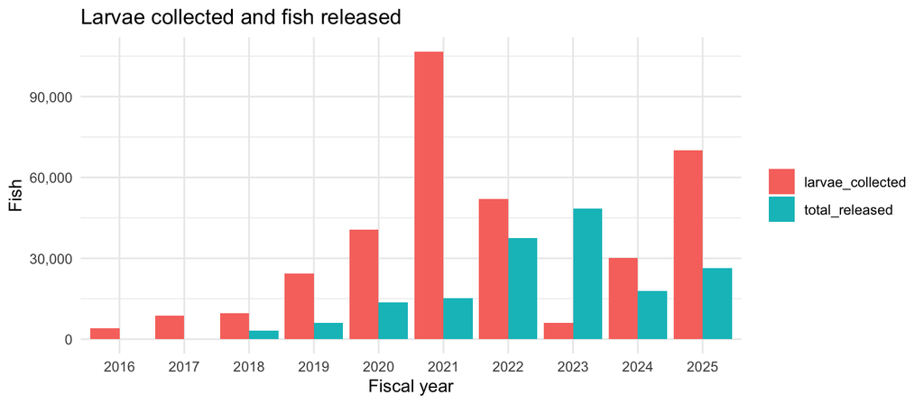

```r
h |>
  select(fiscal_year, larvae_collected, total_released) |>
  pivot_longer(-fiscal_year) |>
  ggplot(aes(factor(fiscal_year), value, fill = name)) +
  geom_col(position = "dodge") +
  scale_y_continuous(labels = scales::comma) +
  labs(x = "Fiscal year", y = "Fish", fill = NULL, title = "Larvae collected and fish released")
```

### Missing values

```r
na_summary(KFNFH_historical_collection_release)
```

| variable | type | missing | pct_missing | rows |
| --- | --- | --- | --- | --- |
| hatchery_name | character | 0 | 0 | 10 |
| fiscal_year | numeric | 0 | 0 | 10 |
| larvae_collected | numeric | 0 | 0 | 10 |
| sarp_release | numeric | 2 | 20 | 10 |
| sarp_tl_mm | numeric | 2 | 20 | 10 |
| fingerling_release | numeric | 8 | 80 | 10 |
| fingerling_tl_mm | numeric | 8 | 80 | 10 |
| fry_release | numeric | 6 | 60 | 10 |
| fry_tl_mm | numeric | 6 | 60 | 10 |
| salvage_release | numeric | 3 | 30 | 10 |
| salvage_sl_mm | numeric | 6 | 60 | 10 |
| salvage_tl_mm | numeric | 7 | 70 | 10 |
| primary_collection_method | character | 0 | 0 | 10 |
| total_released | numeric | 0 | 0 | 10 |
| broodstock_on_station_raw | character | 6 | 60 | 10 |
| broodstock_cohort_years | character | 6 | 60 | 10 |
| new_broodstock_reported | numeric | 9 | 90 | 10 |
| broodstock_on_station | numeric | 6 | 60 | 10 |

## KFNFH_hatchery_release

```r
r <- KFNFH_hatchery_release
o <- "KFNFH_hatchery_release"
qc(o, "number_fish > 0", r$number_fish <= 0)
qc(o, "dispo_date inside its fiscal year", r$dispo_date < fy_start(r$fiscal_year) | r$dispo_date > fy_end(r$fiscal_year))
qc(o, "no duplicate events", duplicated(r[c("fiscal_year", "dispo_date", "species", "lot", "dispo_location", "from_ponds", "number_fish")]))
qc(o, "number_per_lb within 5% of number_fish / weight_lb", abs(r$number_per_lb - r$number_fish / r$weight_lb) / r$number_per_lb > 0.05,
   "rows where the report's fish per pound does not match its own number and weight")

release_vs_history <- r |>
  group_by(fiscal_year) |>
  summarise(distributions = sum(number_fish, na.rm = TRUE), .groups = "drop") |>
  inner_join(KFNFH_historical_collection_release |> select(fiscal_year, total_released), by = "fiscal_year") |>
  mutate(difference = distributions - total_released)
qc(o, "yearly total equals total_released of the historical table (within 1%)", abs(release_vs_history$difference) / release_vs_history$total_released >= 0.01,
   "the distribution table and the collection and release table of the same report do not add to the same total (FY2021 and FY2023, see below)")
qc_table(o)
```

| check | checked | failing | status | note |
| --- | --- | --- | --- | --- |
| number_fish > 0 | 181 | 0 | pass |  |
| dispo_date inside its fiscal year | 181 | 0 | pass |  |
| no duplicate events | 181 | 0 | pass |  |
| number_per_lb within 5% of number_fish / weight_lb | 181 | 0 | pass |  |
| yearly total equals total_released of the historical table (within 1%) | 5 | 1 | FLAG | the distribution table and the collection and release table of the same report do not add to the same total (FY2021 and FY2023, see below) |

```r
release_vs_history
```

| fiscal_year | distributions | total_released | difference |
| --- | --- | --- | --- |
| 2021 | 14643 | 15083 | -440 |
| 2022 | 37416 | 37416 | 0 |
| 2023 | 48377 | 48412 | -35 |
| 2024 | 17866 | 17866 | 0 |
| 2025 | 26454 | 26454 | 0 |

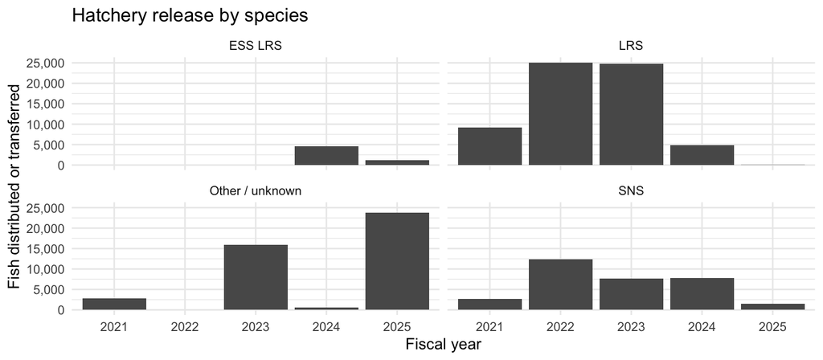

```r
r |>
  mutate(species_group = case_when(str_detect(species, "ESS") ~ "ESS LRS", str_detect(species, "LRS") ~ "LRS", str_detect(species, "SNS|KLS") ~ "SNS", TRUE ~ "Other / unknown")) |>
  summarise(number_fish = sum(number_fish, na.rm = TRUE), .by = c(fiscal_year, species_group)) |>
  ggplot(aes(factor(fiscal_year), number_fish)) +
  geom_col() +
  facet_wrap(~species_group) +
  scale_y_continuous(labels = scales::comma) +
  labs(x = "Fiscal year", y = "Fish distributed or transferred", title = "Hatchery release by species")
```

### Missing values

```r
na_summary(KFNFH_hatchery_release)
```

| variable | type | missing | pct_missing | rows |
| --- | --- | --- | --- | --- |
| hatchery_name | character | 0 | 0.0 | 181 |
| fiscal_year | numeric | 0 | 0.0 | 181 |
| dispo_date | Date | 0 | 0.0 | 181 |
| species | character | 0 | 0.0 | 181 |
| lot | character | 0 | 0.0 | 181 |
| number_fish | numeric | 0 | 0.0 | 181 |
| weight_lb | numeric | 0 | 0.0 | 181 |
| actual_tl_mm | numeric | 59 | 32.6 | 181 |
| number_per_lb | numeric | 0 | 0.0 | 181 |
| projected_tl_inches | numeric | 71 | 39.2 | 181 |
| projected_tl_mm | numeric | 43 | 23.8 | 181 |
| from_ponds | character | 28 | 15.5 | 181 |
| dispo_location | character | 0 | 0.0 | 181 |
| fish_type | character | 153 | 84.5 | 181 |
| tl_inches | numeric | 138 | 76.2 | 181 |
| tl_mm | numeric | 138 | 76.2 | 181 |

## KFNFH_LRS_ESS_adult_collection

```r
a <- KFNFH_LRS_ESS_adult_collection
o <- "KFNFH_LRS_ESS_adult_collection"
qc(o, "sex is Male or Female", !(a$sex %in% c("Male", "Female")), "two FY2023 records with no fish data (a note in the report table)")
qc(o, "fork length 300-1000 mm", a$fl_mm < 300 | a$fl_mm > 1000)
qc(o, "collected inside its fiscal year", a$date < fy_start(a$fiscal_year) | a$date > fy_end(a$fiscal_year))
qc(o, "PIT tag appears once per fiscal year", !is.na(a$pit_tag_last_5) & duplicated(a[c("fiscal_year", "pit_tag_last_5")]),
   "a tag listed twice in the same year (a fish caught twice, or a repeated line in the table)")
qc(o, "fl_in = fl_mm / 25.4", abs(a$fl_in - a$fl_mm / 25.4) > 0.05)
qc_table(o)
```

| check | checked | failing | status | note |
| --- | --- | --- | --- | --- |
| sex is Male or Female | 141 | 2 | FLAG | two FY2023 records with no fish data (a note in the report table) |
| fork length 300-1000 mm | 135 | 0 | pass |  |
| collected inside its fiscal year | 141 | 0 | pass |  |
| PIT tag appears once per fiscal year | 141 | 1 | FLAG | a tag listed twice in the same year (a fish caught twice, or a repeated line in the table) |
| fl_in = fl_mm / 25.4 | 135 | 0 | pass |  |

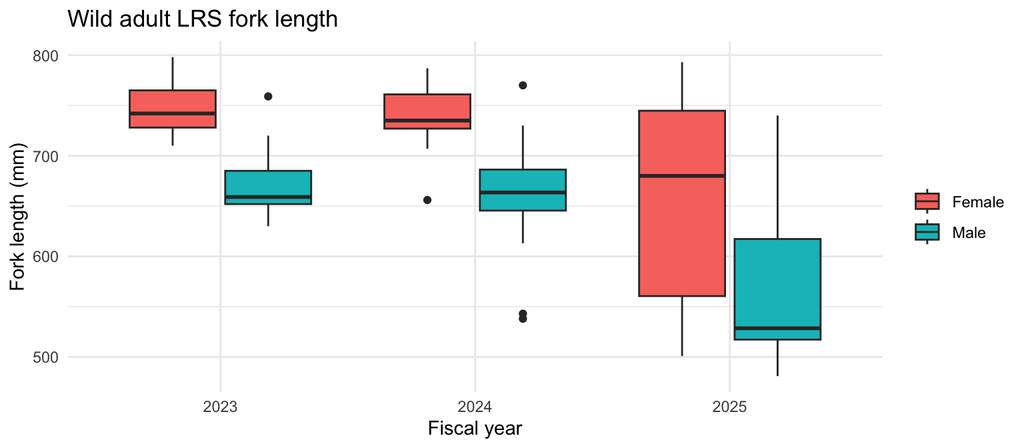

```r
a |>
  filter(!is.na(sex), !is.na(fl_mm)) |>
  ggplot(aes(factor(fiscal_year), fl_mm, fill = sex)) +
  geom_boxplot() +
  labs(x = "Fiscal year", y = "Fork length (mm)", fill = NULL, title = "Wild adult LRS fork length")
```

### Missing values

```r
na_summary(KFNFH_LRS_ESS_adult_collection)
```

| variable | type | missing | pct_missing | rows |
| --- | --- | --- | --- | --- |
| hatchery_name | character | 0 | 0.0 | 141 |
| fiscal_year | numeric | 0 | 0.0 | 141 |
| date | Date | 0 | 0.0 | 141 |
| fin_clip_id_number | character | 35 | 24.8 | 141 |
| pit_tag_suffix | character | 29 | 20.6 | 141 |
| pit_tag_last_5 | character | 2 | 1.4 | 141 |
| sex | character | 2 | 1.4 | 141 |
| gamete_use | character | 2 | 1.4 | 141 |
| fl_mm | numeric | 6 | 4.3 | 141 |
| tl_mm | character | 100 | 70.9 | 141 |
| spring_location | character | 1 | 0.7 | 141 |
| family_groups | numeric | 110 | 78.0 | 141 |
| fl_in | numeric | 6 | 4.3 | 141 |
| atfc_genetic_id | character | 114 | 80.9 | 141 |
| fry_collected_for_aftc | logical | 114 | 80.9 | 141 |

## KFNFH_LRS_ESS_incubation_hatch

```r
i <- KFNFH_LRS_ESS_incubation_hatch
o <- "KFNFH_LRS_ESS_incubation_hatch"
qc(o, "total_eggs within 5% of egg_volume_mL x eggs_per_mL", abs(i$total_eggs - i$egg_volume_mL * i$eggs_per_mL) / i$total_eggs > 0.05)
qc(o, "hatch_percent within 1 point of total_fry / total_eggs", abs(i$hatch_percent - 100 * i$total_fry / i$total_eggs) > 1)
qc(o, "hatch_percent <= 100", i$hatch_percent > 100, "more fry than eggs counted (egg numbers are estimated from volume); values as reported")
qc(o, "spawning in April or May", !(month(i$spawning_date) %in% 4:5))
qc(o, "family_groups = number of males listed", i$family_groups != rowSums(!is.na(i[paste0("male_", 1:6)])))
qc(o, "one row per female, date and incubator", duplicated(i[c("spawning_date", "female", "incubator")]))
qc_table(o)
```

| check | checked | failing | status | note |
| --- | --- | --- | --- | --- |
| total_eggs within 5% of egg_volume_mL x eggs_per_mL | 32 | 0 | pass |  |
| hatch_percent within 1 point of total_fry / total_eggs | 32 | 0 | pass |  |
| hatch_percent <= 100 | 32 | 2 | FLAG | more fry than eggs counted (egg numbers are estimated from volume); values as reported |
| spawning in April or May | 32 | 0 | pass |  |
| family_groups = number of males listed | 32 | 0 | pass |  |
| one row per female, date and incubator | 32 | 0 | pass |  |

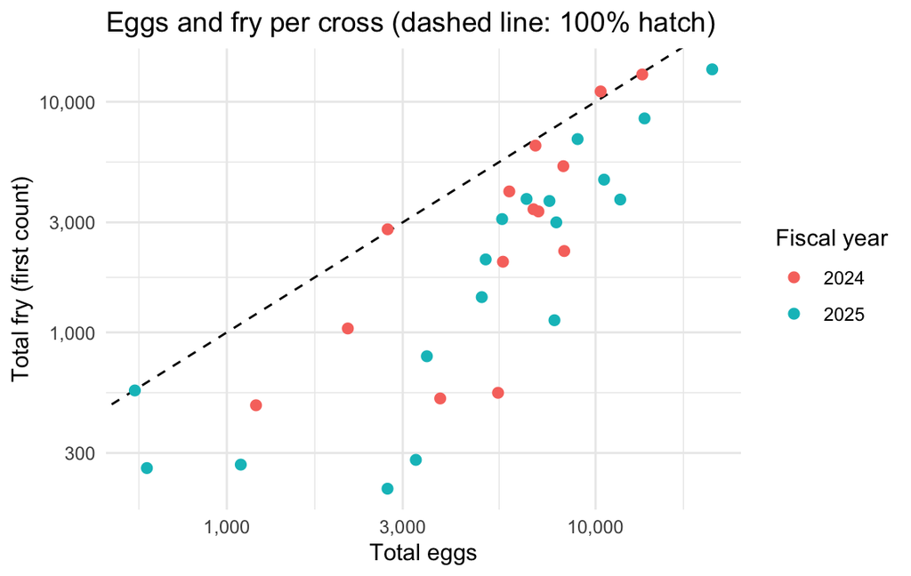

```r
ggplot(i, aes(total_eggs, total_fry, colour = factor(fiscal_year))) +
  geom_abline(slope = 1, linetype = "dashed") +
  geom_point(size = 2) +
  scale_x_log10(labels = scales::comma) + scale_y_log10(labels = scales::comma) +
  labs(x = "Total eggs", y = "Total fry (first count)", colour = "Fiscal year", title = "Eggs and fry per cross (dashed line: 100% hatch)")
```

### Missing values

```r
na_summary(KFNFH_LRS_ESS_incubation_hatch)
```

| variable | type | missing | pct_missing | rows |
| --- | --- | --- | --- | --- |
| hatchery_name | character | 0 | 0.0 | 32 |
| fiscal_year | numeric | 0 | 0.0 | 32 |
| program | character | 0 | 0.0 | 32 |
| species | character | 0 | 0.0 | 32 |
| spawning_date | Date | 0 | 0.0 | 32 |
| female | character | 0 | 0.0 | 32 |
| male_1 | character | 0 | 0.0 | 32 |
| male_2 | character | 2 | 6.2 | 32 |
| male_3 | character | 14 | 43.8 | 32 |
| male_4 | character | 15 | 46.9 | 32 |
| male_5 | character | 30 | 93.8 | 32 |
| male_6 | character | 31 | 96.9 | 32 |
| family_groups | numeric | 0 | 0.0 | 32 |
| incubator | character | 18 | 56.2 | 32 |
| egg_volume_mL | numeric | 0 | 0.0 | 32 |
| eggs_per_mL | numeric | 0 | 0.0 | 32 |
| total_eggs | numeric | 0 | 0.0 | 32 |
| total_fry | numeric | 0 | 0.0 | 32 |
| hatch_percent | numeric | 0 | 0.0 | 32 |
| hatch_date | Date | 18 | 56.2 | 32 |
| second_fry_count | numeric | 14 | 43.8 | 32 |
| second_hatch_percent | numeric | 14 | 43.8 | 32 |

## KFNFH_adfluvial_early_rearing

```r
e <- KFNFH_adfluvial_early_rearing
o <- "KFNFH_adfluvial_early_rearing"
qc(o, "stocked <= collected", e$stocked > e$collected)
qc(o, "survival_percent + observed + unobserved mortality = 100 (1 point)", abs(e$survival_percent + e$observed_mortality_percent + e$unobserved_mortality_percent - 100) > 1)
qc(o, "survival_percent within 1 point of stocked / collected", abs(e$survival_percent - 100 * e$stocked / e$collected) > 1,
   "FY2023 and FY2025 tanks where survival is 1 minus the observed mortality because fish were only counted into the tanks (stated in the FY2025 report)")
qc(o, "collected in May or June", !(month(e$date) %in% 5:6))
qc(o, "no duplicate tank and date", duplicated(e[c("fiscal_year", "date_raw", "culture_unit")]))
qc_table(o)
```

| check | checked | failing | status | note |
| --- | --- | --- | --- | --- |
| stocked <= collected | 54 | 0 | pass |  |
| survival_percent + observed + unobserved mortality = 100 (1 point) | 54 | 0 | pass |  |
| survival_percent within 1 point of stocked / collected | 54 | 7 | FLAG | FY2023 and FY2025 tanks where survival is 1 minus the observed mortality because fish were only counted into the tanks (stated in the FY2025 report) |
| collected in May or June | 54 | 0 | pass |  |
| no duplicate tank and date | 54 | 0 | pass |  |

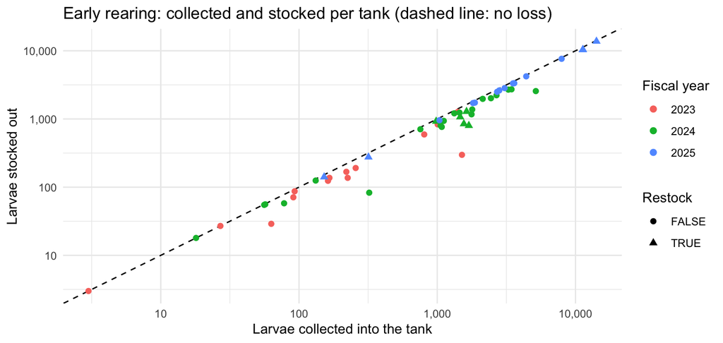

```r
ggplot(e, aes(collected, stocked, colour = factor(fiscal_year), shape = restock)) +
  geom_abline(slope = 1, linetype = "dashed") +
  geom_point(size = 2) +
  scale_x_log10(labels = scales::comma) + scale_y_log10(labels = scales::comma) +
  labs(x = "Larvae collected into the tank", y = "Larvae stocked out", colour = "Fiscal year", shape = "Restock",
       title = "Early rearing: collected and stocked per tank (dashed line: no loss)")
```

### Missing values

```r
na_summary(KFNFH_adfluvial_early_rearing)
```

| variable | type | missing | pct_missing | rows |
| --- | --- | --- | --- | --- |
| hatchery_name | character | 0 | 0 | 54 |
| fiscal_year | numeric | 0 | 0 | 54 |
| date_raw | character | 0 | 0 | 54 |
| date | Date | 0 | 0 | 54 |
| culture_unit | character | 0 | 0 | 54 |
| collected | numeric | 0 | 0 | 54 |
| mortality | numeric | 0 | 0 | 54 |
| stocked | numeric | 0 | 0 | 54 |
| survival_percent | numeric | 0 | 0 | 54 |
| observed_mortality_percent | numeric | 0 | 0 | 54 |
| unobserved_mortality_percent | numeric | 0 | 0 | 54 |
| restock | logical | 0 | 0 | 54 |

## KFNFH_pond_growout

```r
p <- KFNFH_pond_growout
o <- "KFNFH_pond_growout"
has_stock <- !is.na(p$pond_stock_date)
qc(o, "no duplicate cycles (pond, lot, stock date, harvest date)", has_stock & duplicated(p[c("pond", "lot", "pond_stock_date", "harvest_date")]),
   "a cycle listed in two reports that the script did not remove")
qc(o, "harvest after stocking", p$harvest_date < p$pond_stock_date)
qc(o, "days within 3 of harvest_date - pond_stock_date", abs(p$days - as.numeric(p$harvest_date - p$pond_stock_date)) > 3, "FY2022 rows from the OCR'd image tables")
qc(o, "end_number <= start_number", p$end_number > p$start_number, "fish were added to the pond during the cycle (mostly FY2021 Table 3)")
qc(o, "survival_percent within 2 points of end_number / start_number", abs(p$survival_percent - 100 * p$end_number / p$start_number) > 2,
   "the hatchery's survival is not always end/start (negative harvest mortalities, fish moved between ponds); values as reported")
qc(o, "survival_percent between 0 and 110", p$survival_percent < 0 | p$survival_percent > 110, "FY2021 Table 3: more fish at harvest than at stocking")
qc(o, "growth_mm_day within 0.1 of (end_tl_mm - start_tl_mm) / days", abs(p$growth_mm_day - (p$end_tl_mm - p$start_tl_mm) / p$days) > 0.1,
   "FY2023 Table 7 (and 3 FY2024 Table 7 rows): the reported 'mm/day' equals the length change divided by 30, i.e. mm per 30 days")
qc(o, "age_class present for harvested cycles", !is.na(p$harvest_date) & is.na(p$age_class), "lots with no year in the name")
qc(o, "fiscal_year = fiscal year of the harvest date", !is.na(p$harvest_date) & p$fiscal_year != fiscal_year_of(p$harvest_date),
   "fiscal_year is the year of the report that lists the cycle; reports also list cycles harvested just before or after their fiscal year")
qc_table(o)
```

[output not shown]

The script removed 44 duplicated cycles (the same completed cycle listed in two consecutive reports) and kept the later report’s row; the first check above confirms none remain. The growth values that are not mm/day, by report table:

```r
p |>
  filter(!is.na(growth_mm_day), !is.na(days), days > 0) |>
  mutate(calculated = (end_tl_mm - start_tl_mm) / days, calculated_per_30_days = (end_tl_mm - start_tl_mm) / 30) |>
  filter(abs(growth_mm_day - calculated) > 0.1) |>
  summarise(rows = n(), matches_per_30_days = sum(abs(growth_mm_day - calculated_per_30_days) < 0.05), .by = c(fiscal_year, inventory_source))
```

| fiscal_year | inventory_source | rows | matches_per_30_days |
| --- | --- | --- | --- |
| 2023 | FY2023 Table 7 | 1 | 1 |
| 2024 | FY2024 Table 7 | 3 | 0 |

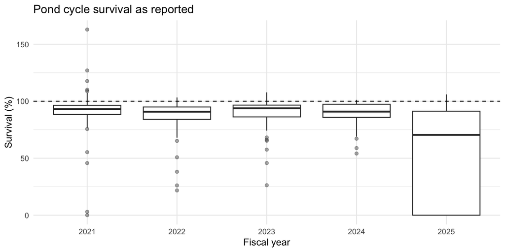

```r
p |>
  filter(!is.na(survival_percent)) |>
  ggplot(aes(factor(fiscal_year), survival_percent)) +
  geom_boxplot(outlier.alpha = 0.4) +
  geom_hline(yintercept = 100, linetype = "dashed") +
  labs(x = "Fiscal year", y = "Survival (%)", title = "Pond cycle survival as reported")
```

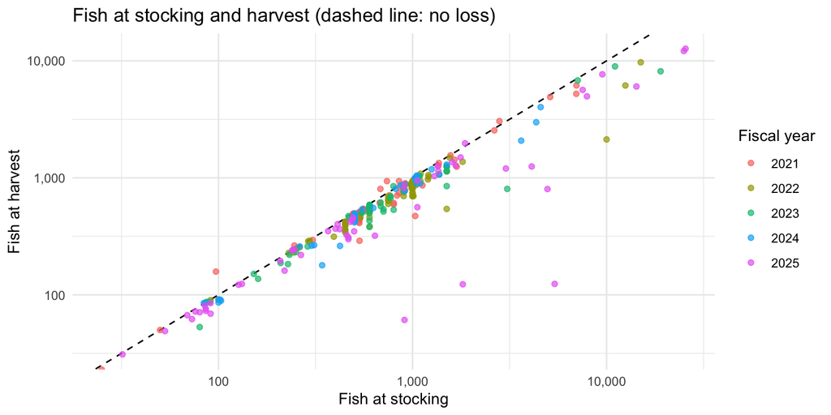

```r
p |>
  filter(!is.na(start_number), !is.na(end_number)) |>
  ggplot(aes(start_number, end_number, colour = factor(fiscal_year))) +
  geom_abline(slope = 1, linetype = "dashed") +
  geom_point(alpha = 0.7) +
  scale_x_log10(labels = scales::comma) + scale_y_log10(labels = scales::comma) +
  labs(x = "Fish at stocking", y = "Fish at harvest", colour = "Fiscal year", title = "Fish at stocking and harvest (dashed line: no loss)")
```

### Missing values

```r
na_summary(KFNFH_pond_growout)
```

| variable | type | missing | pct_missing | rows |
| --- | --- | --- | --- | --- |
| hatchery_name | character | 0 | 0.0 | 359 |
| fiscal_year | numeric | 0 | 0.0 | 359 |
| inventory_source | character | 57 | 15.9 | 359 |
| life_history | character | 0 | 0.0 | 359 |
| source | character | 0 | 0.0 | 359 |
| pond | character | 0 | 0.0 | 359 |
| lot | character | 0 | 0.0 | 359 |
| pond_stock_date | Date | 64 | 17.8 | 359 |
| harvest_date | Date | 38 | 10.6 | 359 |
| start_number | numeric | 19 | 5.3 | 359 |
| start_g_fish | numeric | 167 | 46.5 | 359 |
| start_wt_g | numeric | 167 | 46.5 | 359 |
| start_wt_lb | numeric | 167 | 46.5 | 359 |
| start_tl_mm | numeric | 3 | 0.8 | 359 |
| end_number | numeric | 56 | 15.6 | 359 |
| end_g_fish | numeric | 202 | 56.3 | 359 |
| end_wt_g | numeric | 202 | 56.3 | 359 |
| end_gt_lb | numeric | 323 | 90.0 | 359 |
| end_tl_mm | numeric | 105 | 29.2 | 359 |
| days | numeric | 102 | 28.4 | 359 |
| months | numeric | 202 | 56.3 | 359 |
| growth_mm_day | numeric | 108 | 30.1 | 359 |
| weight_gain_lb | numeric | 257 | 71.6 | 359 |
| harvest_mortality_number | numeric | 37 | 10.3 | 359 |
| survival_percent | numeric | 12 | 3.3 | 359 |
| end_wt_lb | numeric | 238 | 66.3 | 359 |
| weight_gain_g | numeric | 293 | 81.6 | 359 |
| dispo_to | character | 296 | 82.5 | 359 |
| dispo_tl_mm | numeric | 337 | 93.9 | 359 |
| dispo_number | numeric | 295 | 82.2 | 359 |
| dispo_percent | numeric | 331 | 92.2 | 359 |
| short_number | numeric | 339 | 94.4 | 359 |
| short_percent | numeric | 339 | 94.4 | 359 |
| short_tl_mm | numeric | 340 | 94.7 | 359 |
| brood_number | numeric | 337 | 93.9 | 359 |
| brood_percent | numeric | 295 | 82.2 | 359 |
| age_class | character | 40 | 11.1 | 359 |

## KFNFH_pen_survival

```r
n <- KFNFH_pen_survival |> filter(is.na(note))
o <- "KFNFH_pen_survival"
qc(o, "harvested <= stocked", n$number_harvested > n$number_stocked)
qc(o, "survival within 0.2 points of harvested / stocked", abs(n$survival_percentage - 100 * n$number_harvested / n$number_stocked) > 0.2)
qc(o, "rows with a note have no counts", !is.na(KFNFH_pen_survival$note) & !is.na(KFNFH_pen_survival$number_stocked))
qc(o, "one row per pen, operation year and capture year", duplicated(n[c("operation_year", "pen_id", "captured_year")]))
qc_table(o)
```

| check | checked | failing | status | note |
| --- | --- | --- | --- | --- |
| harvested <= stocked | 19 | 0 | pass |  |
| survival within 0.2 points of harvested / stocked | 19 | 0 | pass |  |
| rows with a note have no counts | 23 | 0 | pass |  |
| one row per pen, operation year and capture year | 19 | 0 | pass |  |

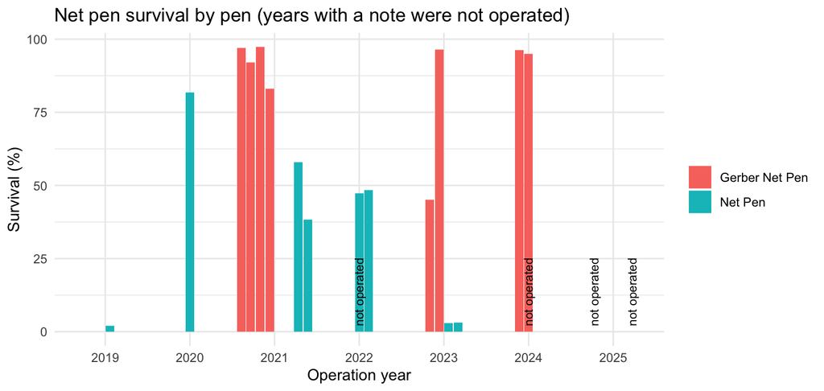

```r
KFNFH_pen_survival |>
  ggplot(aes(factor(operation_year), survival_percentage, fill = pen_type)) +
  geom_col(position = position_dodge2(preserve = "single")) +
  geom_text(data = KFNFH_pen_survival |> filter(!is.na(note)), aes(y = 2, label = "not operated"), angle = 90, hjust = 0, size = 3, position = position_dodge2(width = 0.9, preserve = "single")) +
  labs(x = "Operation year", y = "Survival (%)", fill = NULL, title = "Net pen survival by pen (years with a note were not operated)")
```

### Missing values

```r
na_summary(KFNFH_pen_survival)
```

| variable | type | missing | pct_missing | rows |
| --- | --- | --- | --- | --- |
| hatchery_name | character | 0 | 0.0 | 23 |
| pen_type | character | 0 | 0.0 | 23 |
| operation_year | numeric | 0 | 0.0 | 23 |
| captured_year | numeric | 4 | 17.4 | 23 |
| pen_id | character | 4 | 17.4 | 23 |
| stock_tl_mm | numeric | 4 | 17.4 | 23 |
| number_stocked | numeric | 4 | 17.4 | 23 |
| harvest_tl_mm | numeric | 4 | 17.4 | 23 |
| number_harvested | numeric | 4 | 17.4 | 23 |
| survival_percentage | numeric | 4 | 17.4 | 23 |
| note | character | 19 | 82.6 | 23 |

## KFNFH_fish_movements and KFNFH_cohort_age

```r
mv <- KFNFH_fish_movements
ca <- KFNFH_cohort_age
o <- "KFNFH_fish_movements"
qc(o, "n_fish > 0 when present", mv$n_fish <= 0)
qc(o, "move_date within FY2021-FY2026 when present", mv$move_date < as.Date("2020-10-01") | mv$move_date > as.Date("2026-09-30"))
qc(o, "to_facility is a pond or net pen code", !is.na(mv$to_facility) & !str_detect(mv$to_facility, "^([ABCP]\\d+|GERE|GERW)$"))
qc(o, "source_text is kept for every row", is.na(mv$source_text))
qc(o, "fish moved are within 10% of end_number (cycles where every destination has a number)", abs(cycle_moved$ratio - 1) > 0.1,
   "the cell may leave out a destination or count fish differently; see the table in the section")
qc_table(o)
```

| check | checked | failing | status | note |
| --- | --- | --- | --- | --- |
| n_fish > 0 when present | 246 | 0 | pass |  |
| move_date within FY2021-FY2026 when present | 73 | 0 | pass |  |
| to_facility is a pond or net pen code | 342 | 0 | pass |  |
| source_text is kept for every row | 342 | 0 | pass |  |
| fish moved are within 10% of end_number (cycles where every destination has a number) | 74 | 6 | FLAG | the cell may leave out a destination or count fish differently; see the table in the section |

```r
o <- "KFNFH_cohort_age"
qc(o, "age_at_end is 0-4 or wild when the cohort has a single year", !is.na(ca$cohort_year) & !str_detect(ca$age_at_end, "^[0-4]$"))
qc(o, "age_at_start is not older than age_at_end for single-year cohorts",
   !is.na(ca$cohort_year) & !is.na(ca$age_at_start) & suppressWarnings(as.numeric(ca$age_at_start) > as.numeric(ca$age_at_end)))
qc(o, "rows = pond cycles + net pen groups with a capture year + releases",
   nrow(ca) != nrow(KFNFH_pond_growout) + sum(!is.na(KFNFH_pen_survival$captured_year)) + nrow(KFNFH_hatchery_release))
qc_table(o)
```

| check | checked | failing | status | note |
| --- | --- | --- | --- | --- |
| age_at_end is 0-4 or wild when the cohort has a single year | 523 | 0 | pass |  |
| age_at_start is not older than age_at_end for single-year cohorts | 523 | 0 | pass |  |
| rows = pond cycles + net pen groups with a capture year + releases | 1 | 0 | pass |  |

### Missing values

```r
na_summary(KFNFH_fish_movements)
```

| variable | type | missing | pct_missing | rows |
| --- | --- | --- | --- | --- |
| hatchery_name | character | 0 | 0.0 | 342 |
| fiscal_year | numeric | 0 | 0.0 | 342 |
| from_facility | character | 0 | 0.0 | 342 |
| lot | character | 0 | 0.0 | 342 |
| cycle_stock_date | Date | 196 | 57.3 | 342 |
| cycle_harvest_date | Date | 0 | 0.0 | 342 |
| to_label | character | 0 | 0.0 | 342 |
| to_facility | character | 98 | 28.7 | 342 |
| to_type | character | 0 | 0.0 | 342 |
| n_fish | numeric | 96 | 28.1 | 342 |
| move_date | Date | 269 | 78.7 | 342 |
| date_text | character | 268 | 78.4 | 342 |
| note | character | 304 | 88.9 | 342 |
| source | character | 0 | 0.0 | 342 |
| source_text | character | 0 | 0.0 | 342 |

```r
na_summary(KFNFH_cohort_age)
```

| variable | type | missing | pct_missing | rows |
| --- | --- | --- | --- | --- |
| hatchery_name | character | 0 | 0.0 | 559 |
| cohort | character | 0 | 0.0 | 559 |
| cohort_year | numeric | 38 | 6.8 | 559 |
| stage | character | 0 | 0.0 | 559 |
| facility | character | 28 | 5.0 | 559 |
| fiscal_year | numeric | 0 | 0.0 | 559 |
| start_date | Date | 264 | 47.2 | 559 |
| end_date | Date | 57 | 10.2 | 559 |
| age_at_start | character | 246 | 44.0 | 559 |
| age_at_end | character | 52 | 9.3 | 559 |
| start_number | numeric | 200 | 35.8 | 559 |
| end_number | numeric | 56 | 10.0 | 559 |
| source | character | 57 | 10.2 | 559 |

## KFNFH_mortality_events and KFNFH_mortality_events_summary

```r
ev <- KFNFH_mortality_events
s <- KFNFH_mortality_events_summary
o <- "KFNFH_mortality_events"
tier_rule <- case_when(
  !ev$mortality_event & !is.na(ev$percent_lost) & ev$percent_lost == 0 ~ "Near-miss (no mortality observed)",
  !ev$mortality_event ~ "Non-mortality (escape/collection/reproductive)",
  is.na(ev$percent_lost) ~ "Qualitative only (unquantified)",
  ev$percent_lost > 70 ~ "Catastrophic (>70% loss)",
  ev$percent_lost >= 30 ~ "Major (30-70% loss)",
  ev$percent_lost >= 10 ~ "Moderate (10-30% loss)",
  TRUE ~ "Minor (<10% loss)")
qc(o, "one row per event_id", duplicated(ev$event_id))
qc(o, "percent_lost between 0 and 100", ev$percent_lost < 0 | ev$percent_lost > 100)
qc(o, "severity_tier follows percent_lost", ev$severity_tier != tier_rule)
qc(o, "report_phrase present", is.na(ev$report_phrase))
qc(o, "citation present and names the report of report_year", is.na(ev$citation) | !str_detect(ev$citation, paste0("FY", ev$report_year, " Annual Report")))
qc(o, "loss_source present when percent_lost present", !is.na(ev$percent_lost) & is.na(ev$loss_source))
qc(o, "event year 2019-2025 and not after its report", ev$year < 2019 | ev$year > ev$report_year)
qc(o, "category is one of the six categories", !(ev$category %in% c("disease", "water_quality", "weather", "predation", "equipment", "other")))
o2 <- "KFNFH_mortality_events_summary"
qc(o2, "same events, in the same order, as KFNFH_mortality_events", s$event_id != ev$event_id)
qc(o2, "percent_mortality = percent_lost", abs(coalesce(s$percent_mortality, -1) - coalesce(ev$percent_lost, -1)) > 0.05)
qc(o2, "n_mortality >= 0", s$n_mortality < 0)
qc_table(c(o, o2))
```

| object | check | checked | failing | status | note |
| --- | --- | --- | --- | --- | --- |
| KFNFH_mortality_events | one row per event_id | 37 | 0 | pass |  |
| KFNFH_mortality_events | percent_lost between 0 and 100 | 19 | 0 | pass |  |
| KFNFH_mortality_events | severity_tier follows percent_lost | 37 | 0 | pass |  |
| KFNFH_mortality_events | report_phrase present | 37 | 0 | pass |  |
| KFNFH_mortality_events | citation present and names the report of report_year | 37 | 0 | pass |  |
| KFNFH_mortality_events | loss_source present when percent_lost present | 37 | 0 | pass |  |
| KFNFH_mortality_events | event year 2019-2025 and not after its report | 37 | 0 | pass |  |
| KFNFH_mortality_events | category is one of the six categories | 37 | 0 | pass |  |
| KFNFH_mortality_events_summary | same events, in the same order, as KFNFH_mortality_events | 37 | 0 | pass |  |
| KFNFH_mortality_events_summary | percent_mortality = percent_lost | 37 | 0 | pass |  |
| KFNFH_mortality_events_summary | n_mortality >= 0 | 11 | 0 | pass |  |

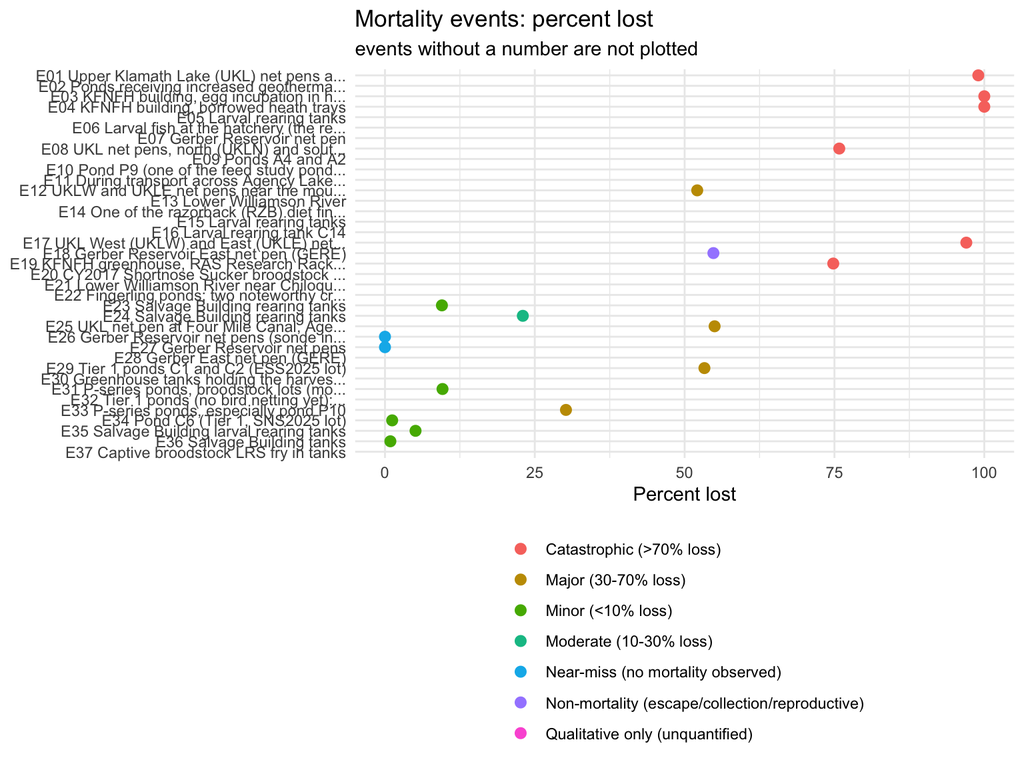

```r
ev |>
  mutate(label = paste(event_id, str_trunc(location, 38)), label = fct_rev(fct_inorder(label))) |>
  ggplot(aes(percent_lost, label, colour = severity_tier)) +
  geom_point(size = 2.5, na.rm = TRUE) +
  labs(x = "Percent lost", y = NULL, colour = NULL, title = "Mortality events: percent lost", subtitle = "events without a number are not plotted") +
  theme(legend.position = "bottom", legend.direction = "vertical")
```

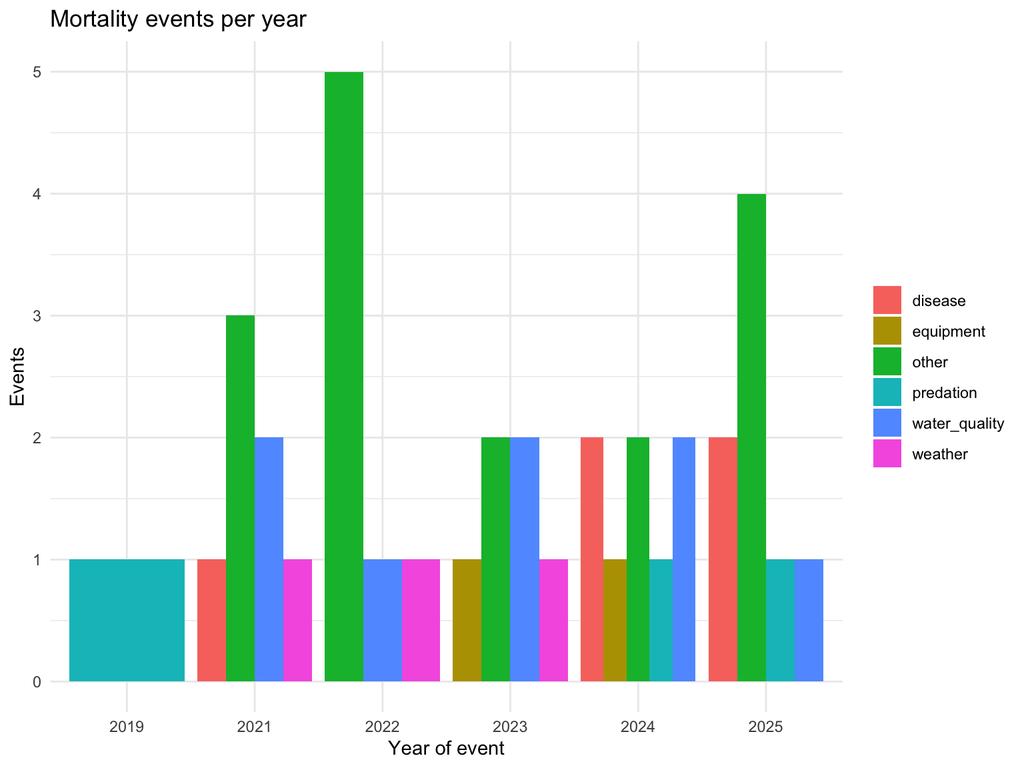

```r
ev |>
  count(year, category) |>
  ggplot(aes(factor(year), n, fill = category)) +
  geom_col(position = "dodge") +
  labs(x = "Year of event", y = "Events", fill = NULL, title = "Mortality events per year")
```

### Missing values

`KFNFH_mortality_events`:

```r
na_summary(KFNFH_mortality_events)
```

| variable | type | missing | pct_missing | rows |
| --- | --- | --- | --- | --- |
| hatchery_name | character | 0 | 0.0 | 37 |
| event_id | character | 0 | 0.0 | 37 |
| year | numeric | 0 | 0.0 | 37 |
| period | character | 0 | 0.0 | 37 |
| location | character | 0 | 0.0 | 37 |
| category | character | 0 | 0.0 | 37 |
| mortality_event | logical | 0 | 0.0 | 37 |
| cause_description | character | 0 | 0.0 | 37 |
| population_affected | character | 0 | 0.0 | 37 |
| loss_as_reported | character | 0 | 0.0 | 37 |
| percent_lost | numeric | 18 | 48.6 | 37 |
| confidence | character | 0 | 0.0 | 37 |
| severity_tier | character | 0 | 0.0 | 37 |
| report_year | numeric | 0 | 0.0 | 37 |
| report_phrase | character | 0 | 0.0 | 37 |
| citation | character | 0 | 0.0 | 37 |
| loss_source | character | 12 | 32.4 | 37 |

`KFNFH_mortality_events_summary`:

```r
na_summary(KFNFH_mortality_events_summary)
```

| variable | type | missing | pct_missing | rows |
| --- | --- | --- | --- | --- |
| hatchery_name | character | 0 | 0.0 | 37 |
| event_id | character | 0 | 0.0 | 37 |
| year | numeric | 0 | 0.0 | 37 |
| category | character | 0 | 0.0 | 37 |
| mortality_event | logical | 0 | 0.0 | 37 |
| percent_mortality | numeric | 18 | 48.6 | 37 |
| n_mortality | numeric | 26 | 70.3 | 37 |

## KFNFH_mortality_pond_monthly

```r
m <- KFNFH_mortality_pond_monthly
o <- "KFNFH_mortality_pond_monthly"
qc(o, "mortality >= 0", m$mortality < 0)
qc(o, "month is a calendar month (harvest records may have none)", !is.na(m$month) & !(m$month %in% month.abb))
qc(o, "record_type is pond or harvest", !(m$record_type %in% c("pond", "harvest")))
qc(o, "one pond record per pond, month and fiscal year", m$record_type == "pond" & duplicated(m[c("fiscal_year", "month", "pond", "record_type")]),
   "FY2024 and FY2025 are daily log rows labelled with their month (the FY2023 sheet is one value per pond and month); sum by month before using as monthly counts")
qc(o, "age_class present", is.na(m$age_class), "months with no pond cycle that has a stock date, and records with no month")
qc_table(o)
```

| check | checked | failing | status | note |
| --- | --- | --- | --- | --- |
| mortality >= 0 | 1516 | 0 | pass |  |
| month is a calendar month (harvest records may have none) | 1516 | 0 | pass |  |
| record_type is pond or harvest | 1516 | 0 | pass |  |
| one pond record per pond, month and fiscal year | 1516 | 1070 | FLAG | FY2024 and FY2025 are daily log rows labelled with their month (the FY2023 sheet is one value per pond and month); sum by month before using as monthly counts |
| age_class present | 1516 | 4 | FLAG | months with no pond cycle that has a stock date, and records with no month |

```r
m |> filter(record_type == "pond") |> group_by(fiscal_year) |> summarise(months_with_records = n_distinct(month), records = n(), mortality = sum(mortality))
```

| fiscal_year | months_with_records | records | mortality |
| --- | --- | --- | --- |
| 2023 | 12 | 133 | 733 |
| 2024 | 10 | 280 | 4790 |
| 2025 | 12 | 1055 | 17136 |

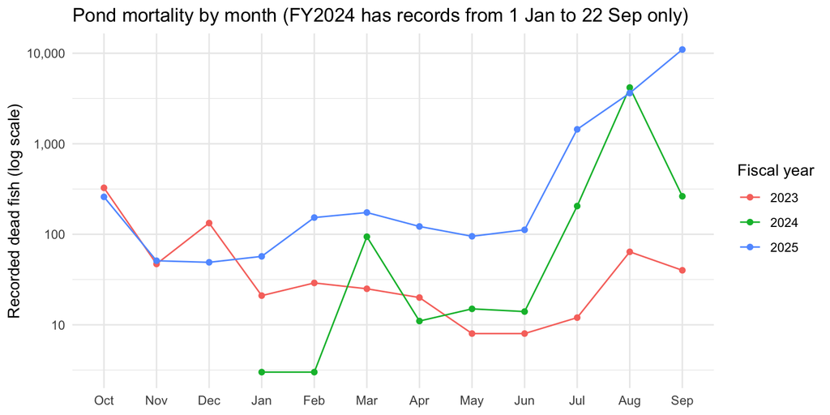

```r
m |>
  filter(record_type == "pond", !is.na(month)) |>
  group_by(fiscal_year, month) |>
  summarise(mortality = sum(mortality), .groups = "drop") |>
  mutate(month = factor(month, levels = c("Oct", "Nov", "Dec", "Jan", "Feb", "Mar", "Apr", "May", "Jun", "Jul", "Aug", "Sep"))) |>
  ggplot(aes(month, mortality, group = fiscal_year, colour = factor(fiscal_year))) +
  geom_line() + geom_point() +
  scale_y_log10(labels = scales::comma) +
  labs(x = NULL, y = "Recorded dead fish (log scale)", colour = "Fiscal year",
       title = "Pond mortality by month (FY2024 has records from 1 Jan to 22 Sep only)")
```

### Missing values

```r
na_summary(KFNFH_mortality_pond_monthly)
```

| variable | type | missing | pct_missing | rows |
| --- | --- | --- | --- | --- |
| hatchery_name | character | 0 | 0.0 | 1516 |
| fiscal_year | numeric | 0 | 0.0 | 1516 |
| month | character | 2 | 0.1 | 1516 |
| pond | character | 0 | 0.0 | 1516 |
| mortality | numeric | 0 | 0.0 | 1516 |
| record_type | character | 0 | 0.0 | 1516 |
| age_class | character | 4 | 0.3 | 1516 |

## KFNFH_capacity

```r
cp <- KFNFH_capacity
o <- "KFNFH_capacity"
qc(o, "ponds and acreage > 0", cp$n_outdoor_ponds <= 0 | cp$acreage_outdoor_ponds <= 0)
qc(o, "one current row per fiscal year", cp$capacity_type == "current" & duplicated(cp$fiscal_year))
qc(o, "indoor gallons present for current years", cp$capacity_type == "current" & is.na(cp$gallons_indoor), "FY2022 has no tank list in the report text that gives gallons")
qc(o, "planned build-out larger than every current year", cp$capacity_type != "current" & cp$acreage_outdoor_ponds <= max(cp$acreage_outdoor_ponds[cp$capacity_type == "current"]))
qc_table(o)
```

| check | checked | failing | status | note |
| --- | --- | --- | --- | --- |
| ponds and acreage > 0 | 6 | 0 | pass |  |
| one current row per fiscal year | 6 | 0 | pass |  |
| indoor gallons present for current years | 6 | 0 | pass |  |
| planned build-out larger than every current year | 6 | 0 | pass |  |

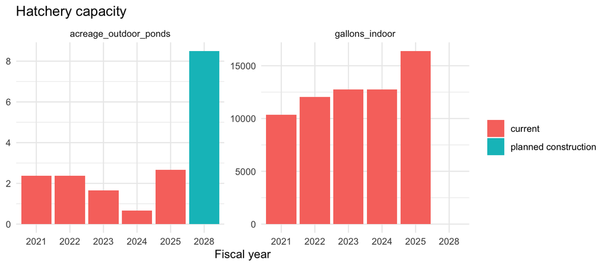

```r
cp |>
  select(fiscal_year, capacity_type, acreage_outdoor_ponds, gallons_indoor) |>
  pivot_longer(c(acreage_outdoor_ponds, gallons_indoor)) |>
  ggplot(aes(factor(fiscal_year), value, fill = capacity_type)) +
  geom_col(position = "dodge", na.rm = TRUE) +
  facet_wrap(~name, scales = "free_y") +
  labs(x = "Fiscal year", y = NULL, fill = NULL, title = "Hatchery capacity")
```

### Missing values

```r
na_summary(KFNFH_capacity)
```

| variable | type | missing | pct_missing | rows |
| --- | --- | --- | --- | --- |
| hatchery_name | character | 0 | 0.0 | 6 |
| fiscal_year | numeric | 0 | 0.0 | 6 |
| n_outdoor_ponds | numeric | 0 | 0.0 | 6 |
| acreage_outdoor_ponds | numeric | 0 | 0.0 | 6 |
| gallons_indoor | numeric | 1 | 16.7 | 6 |
| capacity_type | character | 0 | 0.0 | 6 |

## KFNFH_broodstock_spawned

```r
b <- KFNFH_broodstock_spawned
o <- "KFNFH_broodstock_spawned"
qc(o, "total = females + males", b$total_spawned != b$females_spawned + b$males_spawned)
qc(o, "capture year before the spawning year", b$capture_year >= b$spawn_fiscal_year)
qc(o, "one row per species and capture year", duplicated(b[c("species", "capture_year_raw")]))
qc(o, "species is SNS or LRS", !(b$species %in% c("SNS", "LRS")))
qc_table(o)
```

| check | checked | failing | status | note |
| --- | --- | --- | --- | --- |
| total = females + males | 9 | 0 | pass |  |
| capture year before the spawning year | 8 | 0 | pass |  |
| one row per species and capture year | 9 | 0 | pass |  |
| species is SNS or LRS | 9 | 0 | pass |  |

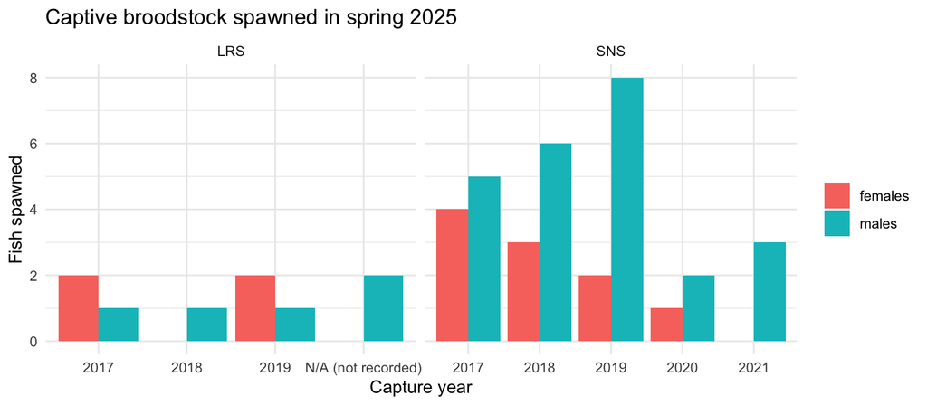

```r
b |>
  select(species, capture_year_raw, females_spawned, males_spawned) |>
  pivot_longer(c(females_spawned, males_spawned), names_to = "sex", names_pattern = "(.*)_spawned") |>
  ggplot(aes(capture_year_raw, value, fill = sex)) +
  geom_col(position = "dodge") +
  facet_wrap(~species, scales = "free_x") +
  labs(x = "Capture year", y = "Fish spawned", fill = NULL, title = "Captive broodstock spawned in spring 2025")
```

### Missing values

```r
na_summary(KFNFH_broodstock_spawned)
```

| variable | type | missing | pct_missing | rows |
| --- | --- | --- | --- | --- |
| hatchery_name | character | 0 | 0.0 | 9 |
| spawn_fiscal_year | numeric | 0 | 0.0 | 9 |
| species | character | 0 | 0.0 | 9 |
| capture_year | numeric | 1 | 11.1 | 9 |
| capture_year_raw | character | 0 | 0.0 | 9 |
| females_spawned | numeric | 0 | 0.0 | 9 |
| males_spawned | numeric | 0 | 0.0 | 9 |
| total_spawned | numeric | 0 | 0.0 | 9 |

## Checks across objects

```r
o <- "across objects"
early_vs_history <- KFNFH_adfluvial_early_rearing |>
  group_by(fiscal_year) |>
  summarise(collected_all_rows = sum(collected), collected_excl_restock = sum(collected[!restock]), .groups = "drop") |>
  inner_join(KFNFH_historical_collection_release |> select(fiscal_year, larvae_collected), by = "fiscal_year") |>
  mutate(closest_difference = pmin(abs(collected_all_rows - larvae_collected), abs(collected_excl_restock - larvae_collected)))
qc(o, "early rearing collected (all rows, or without restock rows) equals larvae_collected of the historical table (within 1 fish)",
   early_vs_history$closest_difference > 1, "FY2023: the report's table rows add to 6,037 and its total row says 6,036")
coverage <- bind_rows(KFNFH_pond_growout |> filter(!is.na(harvest_date)) |> transmute(object = "KFNFH_pond_growout", fiscal_year, ok = !is.na(age_class)),
                      KFNFH_mortality_pond_monthly |> transmute(object = "KFNFH_mortality_pond_monthly", fiscal_year, ok = !is.na(age_class))) |>
  group_by(object, fiscal_year) |>
  summarise(share_with_age_class = mean(ok), .groups = "drop")
qc(o, "age_class present for at least 90% of records in every fiscal year", coverage$share_with_age_class < 0.9)
qc(o, "every FY2025 pond cycle that was harvested has an age class", KFNFH_pond_growout$fiscal_year == 2025 & !is.na(KFNFH_pond_growout$harvest_date) & is.na(KFNFH_pond_growout$age_class))
qc(o, "each FY2025 event cites the FY2025 report", ev$event_id >= "E29" & ev$report_year != 2025)
qc_table(o)
```

| check | checked | failing | status | note |
| --- | --- | --- | --- | --- |
| early rearing collected (all rows, or without restock rows) equals larvae_collected of the historical table (within 1 fish) | 3 | 0 | pass |  |
| age_class present for at least 90% of records in every fiscal year | 8 | 0 | pass |  |
| every FY2025 pond cycle that was harvested has an age class | 359 | 0 | pass |  |
| each FY2025 event cites the FY2025 report | 37 | 0 | pass |  |

```r
early_vs_history
```

| fiscal_year | collected_all_rows | collected_excl_restock | larvae_collected | closest_difference |
| --- | --- | --- | --- | --- |
| 2023 | 6037 | 6037 | 6036 | 1 |
| 2024 | 37477 | 30150 | 30150 | 0 |
| 2025 | 70049 | 32789 | 70049 | 0 |

```r
coverage |> pivot_wider(names_from = fiscal_year, values_from = share_with_age_class)
```

| object | 2023 | 2024 | 2025 | 2021 | 2022 |
| --- | --- | --- | --- | --- | --- |
| KFNFH_mortality_pond_monthly | 0.989 | 0.993 | 1 | NA | NA |
| KFNFH_pond_growout | 1.000 | 0.972 | 1 | 0.984 | 1 |

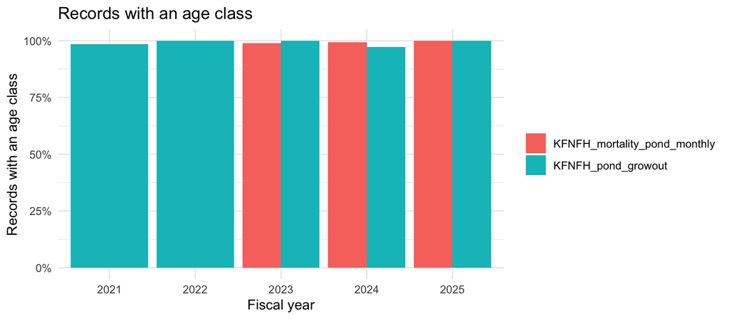

```r
coverage |>
  ggplot(aes(factor(fiscal_year), share_with_age_class, fill = object)) +
  geom_col(position = "dodge") +
  scale_y_continuous(labels = scales::percent, limits = c(0, 1)) +
  labs(x = "Fiscal year", y = "Records with an age class", fill = NULL, title = "Records with an age class")
```

## QC summary

```r
qc_all |>
  summarise(checks = n(), pass = sum(status == "pass"), flagged = sum(status == "FLAG")) |>
  knitr::kable()
```

| checks | pass | flagged |
| --- | --- | --- |
| 76 | 61 | 15 |

```r
qc_all |>
  group_by(object) |>
  summarise(checks = n(), flagged = sum(status == "FLAG"), .groups = "drop") |>
  knitr::kable(format = "html", table.attr = 'class="qc-counts"')
```

| object | checks | flagged |
| --- | --- | --- |
| KFNFH_LRS_ESS_adult_collection | 5 | 2 |
| KFNFH_LRS_ESS_incubation_hatch | 6 | 1 |
| KFNFH_adfluvial_early_rearing | 5 | 1 |
| KFNFH_broodstock_spawned | 4 | 0 |
| KFNFH_capacity | 4 | 0 |
| KFNFH_cohort_age | 3 | 0 |
| KFNFH_fish_movements | 5 | 1 |
| KFNFH_hatchery_release | 5 | 1 |
| KFNFH_historical_collection_release | 6 | 0 |
| KFNFH_mortality_events | 8 | 0 |
| KFNFH_mortality_events_summary | 3 | 0 |
| KFNFH_mortality_pond_monthly | 5 | 2 |
| KFNFH_pen_survival | 4 | 0 |
| KFNFH_pond_growout | 9 | 7 |
| across objects | 4 | 0 |

```r
# missing values: one line per object
map(final_objects, \(o) {
  x <- get(o)
  tibble(object = o, rows = nrow(x), variables = ncol(x), variables_with_missing = sum(map_lgl(x, anyNA)),
         cells_missing_pct = round(100 * mean(is.na(x)), 1))
}) |>
  list_rbind() |>
  knitr::kable(format = "html", table.attr = 'class="qc-counts"')
```

| object | rows | variables | variables_with_missing | cells_missing_pct |
| --- | --- | --- | --- | --- |
| KFNFH_historical_collection_release | 10 | 18 | 13 | 41.7 |
| KFNFH_pond_growout | 359 | 37 | 31 | 43.4 |
| KFNFH_LRS_ESS_adult_collection | 141 | 15 | 12 | 24.6 |
| KFNFH_hatchery_release | 181 | 16 | 7 | 21.8 |
| KFNFH_pen_survival | 23 | 11 | 8 | 18.6 |
| KFNFH_adfluvial_early_rearing | 54 | 12 | 0 | 0.0 |
| KFNFH_LRS_ESS_incubation_hatch | 32 | 22 | 9 | 22.2 |
| KFNFH_fish_movements | 342 | 15 | 6 | 24.0 |
| KFNFH_cohort_age | 559 | 13 | 9 | 13.7 |
| KFNFH_mortality_events | 37 | 17 | 2 | 4.8 |
| KFNFH_mortality_events_summary | 37 | 7 | 2 | 17.0 |
| KFNFH_mortality_pond_monthly | 1516 | 7 | 2 | 0.1 |
| KFNFH_capacity | 6 | 6 | 1 | 2.8 |
| KFNFH_broodstock_spawned | 9 | 8 | 1 | 1.4 |

```r
qc_all |>
  filter(status == "FLAG") |>
  select(object, check, failing = rows_failing, checked = rows_checked, note) |>
  knitr::kable(format = "html", table.attr = 'class="qc-summary"')
```

| object | check | failing | checked | note |
| --- | --- | --- | --- | --- |
| KFNFH_hatchery_release | yearly total equals total_released of the historical table (within 1%) | 1 | 5 | the distribution table and the collection and release table of the same report do not add to the same total (FY2021 and FY2023, see below) |
| KFNFH_LRS_ESS_adult_collection | sex is Male or Female | 2 | 141 | two FY2023 records with no fish data (a note in the report table) |
| KFNFH_LRS_ESS_adult_collection | PIT tag appears once per fiscal year | 1 | 141 | a tag listed twice in the same year (a fish caught twice, or a repeated line in the table) |
| KFNFH_LRS_ESS_incubation_hatch | hatch_percent <= 100 | 2 | 32 | more fry than eggs counted (egg numbers are estimated from volume); values as reported |
| KFNFH_adfluvial_early_rearing | survival_percent within 1 point of stocked / collected | 7 | 54 | FY2023 and FY2025 tanks where survival is 1 minus the observed mortality because fish were only counted into the tanks (stated in the FY2025 report) |
| KFNFH_pond_growout | days within 3 of harvest_date - pond_stock_date | 2 | 257 | FY2022 rows from the OCR’d image tables |
| KFNFH_pond_growout | end_number <= start_number | 10 | 303 | fish were added to the pond during the cycle (mostly FY2021 Table 3) |
| KFNFH_pond_growout | survival_percent within 2 points of end_number / start_number | 72 | 303 | the hatchery’s survival is not always end/start (negative harvest mortalities, fish moved between ponds); values as reported |
| KFNFH_pond_growout | survival_percent between 0 and 110 | 4 | 347 | FY2021 Table 3: more fish at harvest than at stocking |
| KFNFH_pond_growout | growth_mm_day within 0.1 of (end_tl_mm - start_tl_mm) / days | 4 | 251 | FY2023 Table 7 (and 3 FY2024 Table 7 rows): the reported ‘mm/day’ equals the length change divided by 30, i.e. mm per 30 days |
| KFNFH_pond_growout | age_class present for harvested cycles | 2 | 359 | lots with no year in the name |
| KFNFH_pond_growout | fiscal_year = fiscal year of the harvest date | 41 | 359 | fiscal_year is the year of the report that lists the cycle; reports also list cycles harvested just before or after their fiscal year |
| KFNFH_fish_movements | fish moved are within 10% of end_number (cycles where every destination has a number) | 6 | 74 | the cell may leave out a destination or count fish differently; see the table in the section |
| KFNFH_mortality_pond_monthly | one pond record per pond, month and fiscal year | 1070 | 1516 | FY2024 and FY2025 are daily log rows labelled with their month (the FY2023 sheet is one value per pond and month); sum by month before using as monthly counts |
| KFNFH_mortality_pond_monthly | age_class present | 4 | 1516 | months with no pond cycle that has a stock date, and records with no month |

# One age definition everywhere

Every object with a pond or facility has an `age_class` calculated the same way (the monthly mortality takes it from the cohort table):

```r
bind_rows(
  KFNFH_pond_growout |> filter(!is.na(harvest_date)) |> transmute(object = "KFNFH_pond_growout", fiscal_year, matched = !is.na(age_class)),
  KFNFH_mortality_pond_monthly |> transmute(object = "KFNFH_mortality_pond_monthly", fiscal_year, matched = !is.na(age_class))) |>
  group_by(object, fiscal_year) |>
  summarise(rows = n(), with_age = sum(matched), share = round(with_age / rows, 2), .groups = "drop")
```

| object | fiscal_year | rows | with_age | share |
| --- | --- | --- | --- | --- |
| KFNFH_mortality_pond_monthly | 2023 | 181 | 179 | 0.99 |
| KFNFH_mortality_pond_monthly | 2024 | 280 | 278 | 0.99 |
| KFNFH_mortality_pond_monthly | 2025 | 1055 | 1055 | 1.00 |
| KFNFH_pond_growout | 2021 | 64 | 63 | 0.98 |
| KFNFH_pond_growout | 2022 | 100 | 100 | 1.00 |
| KFNFH_pond_growout | 2023 | 66 | 66 | 1.00 |
| KFNFH_pond_growout | 2024 | 36 | 35 | 0.97 |
| KFNFH_pond_growout | 2025 | 55 | 55 | 1.00 |

Pond cycles still in progress (no harvest date, 38 cycles) have no age class and are left out of the pond grow-out counts above. Other records with no age class are lots with no year in the name (pond grow-out) and months with no pond cycle that has a stock date (monthly mortality).

# Description of each data object

All values come from the annual reports (PDF) or the hatchery workbooks (Excel).

```r
descriptions <- tribble(
  ~object, ~contents, ~source, ~years,
  "KFNFH_historical_collection_release", "Larvae collected, SARP, fingerling, fry and salvage releases with lengths, collection method, total released, broodstock on station",
    "FY2025 report Tables 1 and 7; broodstock from the report text; collection totals confirmed in `2025 Larval Collection and Early Rearing Summary Data (version 1).xlsx`", "FY2016-2025",
  "KFNFH_hatchery_release", "Every distribution or transfer of fish: date, species, lot, number, weight, lengths, source pond, destination",
    "FY2021-FY2025 report tables (FY2025 Table 15); FY2025 matches `FY25 Fish Distribution.xlsx`", "FY2021-2025",
  "KFNFH_LRS_ESS_adult_collection", "Wild adult Lost River suckers collected at East Side Springs: date, PIT tag, sex, gamete use, lengths, spring, family groups",
    "FY2023-FY2025 report Table 2; FY2023-24 match the ESS metadata workbooks", "FY2023-2025",
  "KFNFH_LRS_ESS_incubation_hatch", "Spawning crosses per female and incubation vessel: parents, family groups, eggs, fry, hatch percent",
    "FY2024 and FY2025 report Table 3; both years match the ESS metadata workbooks", "FY2024-2025",
  "KFNFH_adfluvial_early_rearing", "Larval culture-unit stocking: collected, mortality, stocked, survival, observed and unobserved mortality, `restock` flag",
    "FY2023 Table 3, FY2024 Table 5, FY2025 Table 8; FY2024 identical to the early rearing workbook", "FY2023-2025",
  "KFNFH_pond_growout", "One row per pond cycle: dates, numbers, weights, lengths, growth, harvest mortality, survival, disposition, `age_class`",
    "FY2021-FY2025 report pond tables; FY2025 cycles validated against the Production Harvest workbook; `age_class` calculated from the lot name. A cycle listed in two consecutive reports is kept once (the later report's row)", "FY2021-2025",
  "KFNFH_pen_survival", "Net pen survival and growth (Upper Klamath Lake and Gerber) with notes for years not operated",
    "FY2024 Tables 9-10 and FY2025 Tables 13-14; identical to `nphistory.xlsx`", "Operation years 2019-2025",
  "KFNFH_fish_movements", "One row per destination of the fish of a pond cycle: from pond, lot, to pond, net pen or other site, number of fish, date, the text it was read from",
    "Production Harvest Data Sheet workbooks (Stocked To column; Disposition on the Spring 2022 sheet) and the FY2021 report pond tables", "FY2021-2025",
  "KFNFH_cohort_age", "Every pond cycle, net pen group and release with its cohort and the age class at the start and end of the stay",
    "Derived from `KFNFH_pond_growout`, `KFNFH_pen_survival` and `KFNFH_hatchery_release`", "FY2021-2025",
  "KFNFH_mortality_events", "37 events from the report narratives: category, location, cause, loss, confidence, severity tier, report year, report phrase, citation (report and page) and loss source",
    "E01-E28: written from the FY2021-2024 report narratives and tables, each tied to a phrase in the report (`report_phrase`) and the report and page in `citation`; loss from `nphistory.xlsx`, larval rearing tables and workbook, report text. E29-E37: `FY25 KFNFH Annual Report.pdf`; loss from `KFNFH_WQ_FY2025_2 (version 1).xlsx` (daily sheets and Sheet1), the Production Harvest workbook, Table 8 and the report text. Tier: fixed rule on the loss", "Events 2019-2025",
  "KFNFH_mortality_events_summary", "Simplified events: category, mortality yes/no, percent mortality, fish lost", "Same as `KFNFH_mortality_events`", "Events 2019-2025",
  "KFNFH_mortality_pond_monthly", "Monthly pond mortality (and FY2023 harvest mortality) with age class",
    "`Fiscal Year 23 WQ_Mortality reporting.xlsx`, `Copy of 2024_KFNFH_WQ.xlsx`, `KFNFH_WQ_FY2025_2 (version 1).xlsx`", "FY2023-2025 (FY2024 is 1 Jan-22 Sep only)",
  "KFNFH_capacity", "Outdoor pond count and acreage, indoor tank gallons, current vs planned",
    "Facility description of the FY2021-FY2025 reports (phrases checked against the report text); gallons summed from the tank lists", "FY2021-2025 plus planned build-out",
  "KFNFH_broodstock_spawned", "Captive broodstock spawned in spring 2025 by capture year, species and sex",
    "`FY25CaptiveBroodSpawning_FINAL.xlsx` (sheet All PIT), identical to FY2025 Table 4", "Spawned in 2025")

descriptions |>
  mutate(rows = map_int(object, ~ nrow(get(.x))),
         cols = map_int(object, ~ ncol(get(.x)))) |>
  relocate(rows, cols, .after = object)
```

| object | rows | cols | contents | source | years |
| --- | --- | --- | --- | --- | --- |
| KFNFH_historical_collection_release | 10 | 18 | Larvae collected, SARP, fingerling, fry and salvage releases with lengths, collection method, total released, broodstock on station | FY2025 report Tables 1 and 7; broodstock from the report text; collection totals confirmed in `2025 Larval Collection and Early Rearing Summary Data (version 1).xlsx` | FY2016-2025 |
| KFNFH_hatchery_release | 181 | 16 | Every distribution or transfer of fish: date, species, lot, number, weight, lengths, source pond, destination | FY2021-FY2025 report tables (FY2025 Table 15); FY2025 matches `FY25 Fish Distribution.xlsx` | FY2021-2025 |
| KFNFH_LRS_ESS_adult_collection | 141 | 15 | Wild adult Lost River suckers collected at East Side Springs: date, PIT tag, sex, gamete use, lengths, spring, family groups | FY2023-FY2025 report Table 2; FY2023-24 match the ESS metadata workbooks | FY2023-2025 |
| KFNFH_LRS_ESS_incubation_hatch | 32 | 22 | Spawning crosses per female and incubation vessel: parents, family groups, eggs, fry, hatch percent | FY2024 and FY2025 report Table 3; both years match the ESS metadata workbooks | FY2024-2025 |
| KFNFH_adfluvial_early_rearing | 54 | 12 | Larval culture-unit stocking: collected, mortality, stocked, survival, observed and unobserved mortality, `restock` flag | FY2023 Table 3, FY2024 Table 5, FY2025 Table 8; FY2024 identical to the early rearing workbook | FY2023-2025 |
| KFNFH_pond_growout | 359 | 37 | One row per pond cycle: dates, numbers, weights, lengths, growth, harvest mortality, survival, disposition, `age_class` | FY2021-FY2025 report pond tables; FY2025 cycles validated against the Production Harvest workbook; `age_class` calculated from the lot name. A cycle listed in two consecutive reports is kept once (the… | FY2021-2025 |
| KFNFH_pen_survival | 23 | 11 | Net pen survival and growth (Upper Klamath Lake and Gerber) with notes for years not operated | FY2024 Tables 9-10 and FY2025 Tables 13-14; identical to `nphistory.xlsx` | Operation years 2019-2025 |
| KFNFH_fish_movements | 342 | 15 | One row per destination of the fish of a pond cycle: from pond, lot, to pond, net pen or other site, number of fish, date, the text it was read from | Production Harvest Data Sheet workbooks (Stocked To column; Disposition on the Spring 2022 sheet) and the FY2021 report pond tables | FY2021-2025 |
| KFNFH_cohort_age | 559 | 13 | Every pond cycle, net pen group and release with its cohort and the age class at the start and end of the stay | Derived from `KFNFH_pond_growout`, `KFNFH_pen_survival` and `KFNFH_hatchery_release` | FY2021-2025 |
| KFNFH_mortality_events | 37 | 17 | 37 events from the report narratives: category, location, cause, loss, confidence, severity tier, report year, report phrase, citation (report and page) and loss source | E01-E28: written from the FY2021-2024 report narratives and tables, each tied to a phrase in the report (`report_phrase`) and the report and page in `citation`; loss from `nphistory.xlsx`, larval rear… | Events 2019-2025 |
| KFNFH_mortality_events_summary | 37 | 7 | Simplified events: category, mortality yes/no, percent mortality, fish lost | Same as `KFNFH_mortality_events` | Events 2019-2025 |
| KFNFH_mortality_pond_monthly | 1516 | 7 | Monthly pond mortality (and FY2023 harvest mortality) with age class | `Fiscal Year 23 WQ_Mortality reporting.xlsx`, `Copy of 2024_KFNFH_WQ.xlsx`, `KFNFH_WQ_FY2025_2 (version 1).xlsx` | FY2023-2025 (FY2024 is 1 Jan-22 Sep only) |
| KFNFH_capacity | 6 | 6 | Outdoor pond count and acreage, indoor tank gallons, current vs planned | Facility description of the FY2021-FY2025 reports (phrases checked against the report text); gallons summed from the tank lists | FY2021-2025 plus planned build-out |
| KFNFH_broodstock_spawned | 9 | 8 | Captive broodstock spawned in spring 2025 by capture year, species and sex | `FY25CaptiveBroodSpawning_FINAL.xlsx` (sheet All PIT), identical to FY2025 Table 4 | Spawned in 2025 |

# Draft data dictionary

One row per column of each data object, with its type, a description and the source of its values. The descriptions are the ones in `R/data.R` (they are parsed from the roxygen blocks, so editing them there updates this table). The source is a PDF title, or a workbook and sheet name; a column whose source differs from the rest of its object has its own entry. This is a draft: columns that are not described in `R/data.R` show as “TODO”, and the table is also written to `data-raw/hatchery_data_dictionary.csv`.

```r
pdf_2021 <- "20240912_FY2021_KFNFH_Annual_Report_Final.pdf"
pdf_2022 <- "20240830_FY2022 KFNFH Annual Report_Final.pdf"
pdf_2023 <- "20240801_FY2023 KFNFH Annual Report_Final.pdf"
pdf_2024 <- "20250619_FY2024 KFNFH Annual Report_Final Draft.pdf"
pdf_2025 <- "FY25 KFNFH Annual Report.pdf"

dictionary_objects <- final_objects
get_object <- function(name) get(name)

# descriptions: \item \code{column}: text lines of each roxygen block in R/data.R
parse_data_r <- function(path) {
  lines <- readLines(path)
  starts <- which(str_detect(lines, "^#' @name "))
  map2(starts, c(starts[-1] - 1, length(lines)), function(from, to) {
    block <- lines[from:to]
    items <- block[str_detect(block, "^#'\\s+\\\\item \\\\code\\{")]
    tibble(object = str_trim(str_remove(lines[from], "^#' @name ")),
           column = str_trim(str_match(items, "\\\\code\\{([^}]+)\\}")[, 2]),
           description = items |>
             str_remove("^#'\\s+\\\\item \\\\code\\{[^}]+\\}:?\\s*") |>
             str_replace_all("\\\\code\\{([^}]*)\\}", "`\\1`") |>
             str_replace_all("\\\\%", "%") |>
             str_squish())
  }) |> list_rbind()
}
documented <- parse_data_r(here::here("R/data.R"))

# default source of each object
source_default <- tribble(
  ~object, ~source,
  "KFNFH_historical_collection_release", paste0(pdf_2025, ", Table 1"),
  "KFNFH_hatchery_release", paste0(pdf_2025, ", Table 15; ", pdf_2024, ", Table 11; ", pdf_2023, ", Table 10; ", pdf_2022, ", Table 5; ", pdf_2021, ", Table 2"),
  "KFNFH_LRS_ESS_adult_collection", paste0(pdf_2025, ", Table 2; ", pdf_2024, ", Table 2; ", pdf_2023, ", Table 2"),
  "KFNFH_LRS_ESS_incubation_hatch", paste0(pdf_2024, ", Table 3 (FY2024 rows); FY25 METADATA FOR ALL ESS LRS FISH SPAWNED.xlsx, sheet 'FY25 Tables Reorganized ' (FY2025 rows, same as ", pdf_2025, ", Table 3)"),
  "KFNFH_adfluvial_early_rearing", paste0(pdf_2025, ", Table 8; ", pdf_2024, ", Table 5; ", pdf_2023, ", Table 3"),
  "KFNFH_pond_growout", paste0(pdf_2025, ", Tables 10-12; ", pdf_2024, ", Tables 6-8; ", pdf_2023, ", Tables 5-7; ", pdf_2022, ", Tables 2-4; ", pdf_2021, ", Tables 3-4"),
  "KFNFH_pen_survival", paste0("nphistory.xlsx, sheets UKL and Gerber (same as ", pdf_2025, ", Tables 13-14 and ", pdf_2024, ", Tables 9-10)"),
  "KFNFH_fish_movements", "Production Harvest Data Sheet.xlsx (FY2024 folder), sheets Spring 2022, SPRING 2023, FALL 2023, SPRING 2024, column Stocked To (Disposition OUT OF ORDER on Spring 2022); FY2025 Production Harvest Data Sheet_20251107.xlsx, sheets FALL 2024, Spring 2025, Fall 2025, column Stocked To/#; FY2021 report tables 3-4, disposition column",
  "KFNFH_cohort_age", "Derived from KFNFH_pond_growout, KFNFH_pen_survival and KFNFH_hatchery_release (same sources)",
  "KFNFH_mortality_events", paste0(pdf_2021, ", ", pdf_2022, ", ", pdf_2023, ", ", pdf_2024, " (narrative sections, E01-E28); ", pdf_2025, " (narrative, E29-E37)"),
  "KFNFH_mortality_events_summary", "Derived from KFNFH_mortality_events (same sources)",
  "KFNFH_mortality_pond_monthly", "Fiscal Year 23 WQ_Mortality reporting.xlsx, sheets Pond Mortality FY 23 and Harvest Morts FY 23; Copy of 2024_KFNFH_WQ.xlsx, sheets JanToMar_WQ, ApriltoJune_WQ, JulytoSeptember_WQ; KFNFH_WQ_FY2025_2 (version 1).xlsx, sheets OctobertoDecember_WQ, JantoMar_WQ, AprtoJun_WQ, JulytoSept_WQ",
  "KFNFH_capacity", paste0(pdf_2021, ", ", pdf_2022, ", ", pdf_2023, ", ", pdf_2024, ", ", pdf_2025, " (facility description sections)"),
  "KFNFH_broodstock_spawned", "FY25CaptiveBroodSpawning_FINAL.xlsx, sheet All PIT (same as FY25 KFNFH Annual Report.pdf, Table 4)"
)

# columns whose source differs from the rest of the object ("*" = every object)
source_overrides <- tribble(
  ~object, ~column, ~source,
  "*", "hatchery_name", "constant (KFNFH)",
  "KFNFH_historical_collection_release", "larvae_collected", paste0(pdf_2025, ", Table 7 (confirmed in 2025 Larval Collection and Early Rearing Summary Data (version 1).xlsx, sheet 2025 Sucker Early Rearing)"),
  "KFNFH_historical_collection_release", "primary_collection_method", paste0(pdf_2025, ", Table 7"),
  "KFNFH_historical_collection_release", "total_released", paste0(pdf_2025, ", Table 1 (sum of the four release columns)"),
  "KFNFH_historical_collection_release", "broodstock_on_station_raw", paste0("report text of ", pdf_2021, ", ", pdf_2023, ", ", pdf_2024, ", ", pdf_2025),
  "KFNFH_historical_collection_release", "broodstock_cohort_years", paste0("report text of ", pdf_2021, ", ", pdf_2023, ", ", pdf_2024, ", ", pdf_2025),
  "KFNFH_historical_collection_release", "new_broodstock_reported", paste0("report text of ", pdf_2021),
  "KFNFH_historical_collection_release", "broodstock_on_station", "parsed from broodstock_on_station_raw",
  "KFNFH_hatchery_release", "dispo_date", paste0("report tables above; FY2025 also in FY25 Fish Distribution.xlsx, sheet FY25 Distribution Table"),
  "KFNFH_LRS_ESS_incubation_hatch", "program", "METADATA FOR ALL ESS LRS FISH SPAWNED (version 1).xlsx and FY25 METADATA FOR ALL ESS LRS FISH SPAWNED.xlsx (constant: Wild ESS Spawning)",
  "KFNFH_LRS_ESS_incubation_hatch", "species", "same workbooks (constant: LRS)",
  "KFNFH_LRS_ESS_incubation_hatch", "family_groups", "METADATA FOR ALL ESS LRS FISH SPAWNED (version 1).xlsx, sheet FY24 Tables Reorganized - MY (number of males); FY25 METADATA FOR ALL ESS LRS FISH SPAWNED.xlsx, sheet FY25 Tables Reorganized ",
  "KFNFH_adfluvial_early_rearing", "restock", "derived from culture_unit",
  "KFNFH_adfluvial_early_rearing", "date", "first date in date_raw",
  "KFNFH_pond_growout", "fiscal_year", "fiscal year of the report table",
  "KFNFH_pond_growout", "source", "derived (annual_report_table or production_harvest_workbook)",
  "KFNFH_pond_growout", "age_class", "derived (fiscal year the cycle ended minus the year in the lot name)",
  "KFNFH_pen_survival", "note", "nphistory.xlsx, sheets UKL and Gerber (text in the stock columns)",
  "KFNFH_mortality_events", "report_year", "derived (report whose narrative describes the event)",
  "KFNFH_mortality_events", "report_phrase", "phrase copied from the report named by report_year (the sources of the events table)",
  "KFNFH_mortality_events", "citation", "report and page(s) of the annual report PDFs that the event is taken from (the text of the row)",
  "KFNFH_mortality_events", "percent_lost", "see loss_source: nphistory.xlsx (sheets UKL, Gerber); 2024 Larval Collection and Early Rearing Summary Data.xlsx, sheet Pond Performance Table 4 Report; FY2023 report tables; report text; E29-E37: KFNFH_WQ_FY2025_2 (version 1).xlsx (Sheet1 and the daily sheets), FY2025 Production Harvest Data Sheet_20251107.xlsx, FY25 report Table 8",
  "KFNFH_mortality_events", "severity_tier", "derived from percent_lost by a fixed rule",
  "KFNFH_mortality_events", "loss_source", "see percent_lost",
  "KFNFH_mortality_events_summary", "percent_mortality", "see KFNFH_mortality_events$loss_source",
  "KFNFH_mortality_events_summary", "n_mortality", "see KFNFH_mortality_events$loss_source",
  "KFNFH_mortality_pond_monthly", "record_type", "derived (pond: daily or monthly pond sheets; harvest: sheet Harvest Morts FY 23)",
  "KFNFH_mortality_pond_monthly", "age_class", "derived from KFNFH_cohort_age (pond cycles in the pond that month)",
  "KFNFH_capacity", "gallons_indoor", paste0("tank lists in ", pdf_2021, ", ", pdf_2022, ", ", pdf_2023, ", ", pdf_2024, ", ", pdf_2025),
  "KFNFH_broodstock_spawned", "spawn_fiscal_year", "constant (2025)"
)

data_dictionary <- map(dictionary_objects, function(o) {
  x <- get_object(o)
  tibble(object = o, column = names(x), type = map_chr(x, \(v) class(v)[1]))
}) |>
  list_rbind() |>
  left_join(documented, by = c("object", "column")) |>
  left_join(source_default, by = "object") |>
  left_join(source_overrides |> filter(object != "*") |> rename(source_override = source), by = c("object", "column")) |>
  left_join(source_overrides |> filter(object == "*") |> select(column, source_all = source), by = "column") |>
  transmute(object, column, type,
            description = coalesce(description, "TODO: not described in R/data.R"),
            data_source = coalesce(source_override, source_all, source))

write_csv(data_dictionary, here::here("data-raw", "hatchery_data_dictionary.csv"))

# described in R/data.R but not a column of the object, and columns with no description
documented |>
  filter(object %in% dictionary_objects) |>
  anti_join(data_dictionary, by = c("object", "column"))
```

| object | column | description |
| --- | --- | --- |

```r
data_dictionary |> filter(str_detect(description, "^TODO")) |> select(object, column)
```

| object | column |
| --- | --- |

```r
for (o in dictionary_objects) {
  cat("\n\n## ", o, "\n\n", sep = "")
  data_dictionary |>
    filter(object == o) |>
    select(column, type, description, data_source) |>
    knitr::kable(format = "html", table.attr = 'class="dict"') |>
    print()
}
```

## KFNFH_historical_collection_release

| column | type | description | data_source |
| --- | --- | --- | --- |
| hatchery_name | character | name of hatchery (KFNFH) | constant (KFNFH) |
| fiscal_year | numeric | fiscal year | FY25 KFNFH Annual Report.pdf, Table 1 |
| larvae_collected | numeric | number of wild larval suckers collected | FY25 KFNFH Annual Report.pdf, Table 7 (confirmed in 2025 Larval Collection and Early Rearing Summary Data (version 1).xlsx, sheet 2025 Sucker Early Rearing) |
| sarp_release | numeric | number of fish released or transferred that were raised in the Sucker Assisted Rearing Program (SARP) | FY25 KFNFH Annual Report.pdf, Table 1 |
| sarp_tl_mm | numeric | average total length (TL) of the SARP release fish, measured in millimeters (mm) | FY25 KFNFH Annual Report.pdf, Table 1 |
| fingerling_release | numeric | number of fingerlings released or transferred | FY25 KFNFH Annual Report.pdf, Table 1 |
| fingerling_tl_mm | numeric | average total length (TL) of the fingerling release fish, measured in millimeters (mm) | FY25 KFNFH Annual Report.pdf, Table 1 |
| fry_release | numeric | number of fry released or transferred. This includes fry produced from experimental, wild-spawning activities that were transferred to other facilities (e.g., the Klamath Tribes Hatchery in FY24 and F… | FY25 KFNFH Annual Report.pdf, Table 1 |
| fry_tl_mm | numeric | average total length (TL) of the fry release fish, measured in millimeters (mm) | FY25 KFNFH Annual Report.pdf, Table 1 |
| salvage_release | numeric | number of suckers salvaged throughout the year | FY25 KFNFH Annual Report.pdf, Table 1 |
| salvage_sl_mm | numeric | average standard length (SL) of salvage fish in millimeters (mm), reported in years where the report gives standard length | FY25 KFNFH Annual Report.pdf, Table 1 |
| salvage_tl_mm | numeric | average total length (TL) of salvage fish in millimeters (mm), reported in years where the report gives total length | FY25 KFNFH Annual Report.pdf, Table 1 |
| primary_collection_method | character | drift net, dip net, or both | FY25 KFNFH Annual Report.pdf, Table 7 |
| total_released | numeric | total number of fish released across release types | FY25 KFNFH Annual Report.pdf, Table 1 (sum of the four release columns) |
| broodstock_on_station_raw | character | broodstock currently on station, as written in the report | report text of 20240912_FY2021_KFNFH_Annual_Report_Final.pdf, 20240801_FY2023 KFNFH Annual Report_Final.pdf, 20250619_FY2024 KFNFH Annual Report_Final Draft.pdf, FY25 KFNFH Annual Report.pdf |
| broodstock_cohort_years | character | capture years of the broodstock on station, as written in the report | report text of 20240912_FY2021_KFNFH_Annual_Report_Final.pdf, 20240801_FY2023 KFNFH Annual Report_Final.pdf, 20250619_FY2024 KFNFH Annual Report_Final Draft.pdf, FY25 KFNFH Annual Report.pdf |
| new_broodstock_reported | numeric | number of new broodstock reported | report text of 20240912_FY2021_KFNFH_Annual_Report_Final.pdf |
| broodstock_on_station | numeric | leading number parsed from `broodstock_on_station_raw`; a rounded or minimum estimate, not an exact count | parsed from broodstock_on_station_raw |

## KFNFH_pond_growout

[output not shown]

## KFNFH_LRS_ESS_adult_collection

| column | type | description | data_source |
| --- | --- | --- | --- |
| hatchery_name | character | hatchery name (KFNFH) | constant (KFNFH) |
| fiscal_year | numeric | fiscal year (2023-2025) | FY25 KFNFH Annual Report.pdf, Table 2; 20250619_FY2024 KFNFH Annual Report_Final Draft.pdf, Table 2; 20240801_FY2023 KFNFH Annual Report_Final.pdf, Table 2 |
| date | Date | date adults were collected | FY25 KFNFH Annual Report.pdf, Table 2; 20250619_FY2024 KFNFH Annual Report_Final Draft.pdf, Table 2; 20240801_FY2023 KFNFH Annual Report_Final.pdf, Table 2 |
| fin_clip_id_number | character | fin clip identification number | FY25 KFNFH Annual Report.pdf, Table 2; 20250619_FY2024 KFNFH Annual Report_Final Draft.pdf, Table 2; 20240801_FY2023 KFNFH Annual Report_Final.pdf, Table 2 |
| pit_tag_suffix | character | PIT tag suffix (FY2024 and FY2025) | FY25 KFNFH Annual Report.pdf, Table 2; 20250619_FY2024 KFNFH Annual Report_Final Draft.pdf, Table 2; 20240801_FY2023 KFNFH Annual Report_Final.pdf, Table 2 |
| pit_tag_last_5 | character | last five characters of the PIT tag | FY25 KFNFH Annual Report.pdf, Table 2; 20250619_FY2024 KFNFH Annual Report_Final Draft.pdf, Table 2; 20240801_FY2023 KFNFH Annual Report_Final.pdf, Table 2 |
| sex | character | sex of the adult fish | FY25 KFNFH Annual Report.pdf, Table 2; 20250619_FY2024 KFNFH Annual Report_Final Draft.pdf, Table 2; 20240801_FY2023 KFNFH Annual Report_Final.pdf, Table 2 |
| gamete_use | character | whether gametes were used (e.g. Spawned, Not Spawned; FY2025 includes the reason, e.g. “Not Spawned/No Eggs”) | FY25 KFNFH Annual Report.pdf, Table 2; 20250619_FY2024 KFNFH Annual Report_Final Draft.pdf, Table 2; 20240801_FY2023 KFNFH Annual Report_Final.pdf, Table 2 |
| fl_mm | numeric | fork length (mm) | FY25 KFNFH Annual Report.pdf, Table 2; 20250619_FY2024 KFNFH Annual Report_Final Draft.pdf, Table 2; 20240801_FY2023 KFNFH Annual Report_Final.pdf, Table 2 |
| tl_mm | character | total length (mm); reported in FY2024 only | FY25 KFNFH Annual Report.pdf, Table 2; 20250619_FY2024 KFNFH Annual Report_Final Draft.pdf, Table 2; 20240801_FY2023 KFNFH Annual Report_Final.pdf, Table 2 |
| spring_location | character | spring or location where the fish was collected | FY25 KFNFH Annual Report.pdf, Table 2; 20250619_FY2024 KFNFH Annual Report_Final Draft.pdf, Table 2; 20240801_FY2023 KFNFH Annual Report_Final.pdf, Table 2 |
| family_groups | numeric | number of family groups the female was crossed into (FY2024 and FY2025) | FY25 KFNFH Annual Report.pdf, Table 2; 20250619_FY2024 KFNFH Annual Report_Final Draft.pdf, Table 2; 20240801_FY2023 KFNFH Annual Report_Final.pdf, Table 2 |
| fl_in | numeric | fork length (inches) | FY25 KFNFH Annual Report.pdf, Table 2; 20250619_FY2024 KFNFH Annual Report_Final Draft.pdf, Table 2; 20240801_FY2023 KFNFH Annual Report_Final.pdf, Table 2 |
| atfc_genetic_id | character | Abernathy Fish Technology Center genetic ID (FY2023) | FY25 KFNFH Annual Report.pdf, Table 2; 20250619_FY2024 KFNFH Annual Report_Final Draft.pdf, Table 2; 20240801_FY2023 KFNFH Annual Report_Final.pdf, Table 2 |
| fry_collected_for_aftc | logical | whether fry were collected for genetic analysis by the Abernathy Fish Technology Center (FY2023) | FY25 KFNFH Annual Report.pdf, Table 2; 20250619_FY2024 KFNFH Annual Report_Final Draft.pdf, Table 2; 20240801_FY2023 KFNFH Annual Report_Final.pdf, Table 2 |

## KFNFH_hatchery_release

| column | type | description | data_source |
| --- | --- | --- | --- |
| hatchery_name | character | name of hatchery (KFNFH) | constant (KFNFH) |
| fiscal_year | numeric | fiscal year (2021-2025) | FY25 KFNFH Annual Report.pdf, Table 15; 20250619_FY2024 KFNFH Annual Report_Final Draft.pdf, Table 11; 20240801_FY2023 KFNFH Annual Report_Final.pdf, Table 10; 20240830_FY2022 KFNFH Annual Report_Fina… |
| dispo_date | Date | date the fish distribution or transfer event occurred | report tables above; FY2025 also in FY25 Fish Distribution.xlsx, sheet FY25 Distribution Table |
| species | character | species of sucker being distributed (e.g. LRS, SNS, ESS LRS) | FY25 KFNFH Annual Report.pdf, Table 15; 20250619_FY2024 KFNFH Annual Report_Final Draft.pdf, Table 11; 20240801_FY2023 KFNFH Annual Report_Final.pdf, Table 10; 20240830_FY2022 KFNFH Annual Report_Fina… |
| lot | character | grouping or cohort of fish categorized primarily by their collection year (CY) or their operational origin | FY25 KFNFH Annual Report.pdf, Table 15; 20250619_FY2024 KFNFH Annual Report_Final Draft.pdf, Table 11; 20240801_FY2023 KFNFH Annual Report_Final.pdf, Table 10; 20240830_FY2022 KFNFH Annual Report_Fina… |
| number_fish | numeric | number of fish in that specific grouping (lot) that were distributed or transferred | FY25 KFNFH Annual Report.pdf, Table 15; 20250619_FY2024 KFNFH Annual Report_Final Draft.pdf, Table 11; 20240801_FY2023 KFNFH Annual Report_Final.pdf, Table 10; 20240830_FY2022 KFNFH Annual Report_Fina… |
| weight_lb | numeric | total weight of the fish lot being distributed, measured in pounds (lb) | FY25 KFNFH Annual Report.pdf, Table 15; 20250619_FY2024 KFNFH Annual Report_Final Draft.pdf, Table 11; 20240801_FY2023 KFNFH Annual Report_Final.pdf, Table 10; 20240830_FY2022 KFNFH Annual Report_Fina… |
| actual_tl_mm | numeric | actual total length (TL) of the fish, measured in millimeters (mm) | FY25 KFNFH Annual Report.pdf, Table 15; 20250619_FY2024 KFNFH Annual Report_Final Draft.pdf, Table 11; 20240801_FY2023 KFNFH Annual Report_Final.pdf, Table 10; 20240830_FY2022 KFNFH Annual Report_Fina… |
| number_per_lb | numeric | number of fish per pound for the specific lot being distributed | FY25 KFNFH Annual Report.pdf, Table 15; 20250619_FY2024 KFNFH Annual Report_Final Draft.pdf, Table 11; 20240801_FY2023 KFNFH Annual Report_Final.pdf, Table 10; 20240830_FY2022 KFNFH Annual Report_Fina… |
| projected_tl_inches | numeric | projected total length (TL) of the fish, measured in inches | FY25 KFNFH Annual Report.pdf, Table 15; 20250619_FY2024 KFNFH Annual Report_Final Draft.pdf, Table 11; 20240801_FY2023 KFNFH Annual Report_Final.pdf, Table 10; 20240830_FY2022 KFNFH Annual Report_Fina… |
| projected_tl_mm | numeric | projected total length (TL) of the fish, measured in millimeters (mm) | FY25 KFNFH Annual Report.pdf, Table 15; 20250619_FY2024 KFNFH Annual Report_Final Draft.pdf, Table 11; 20240801_FY2023 KFNFH Annual Report_Final.pdf, Table 10; 20240830_FY2022 KFNFH Annual Report_Fina… |
| from_ponds | character | source location within the hatchery facility from which the fish were harvested just prior to distribution or transfer | FY25 KFNFH Annual Report.pdf, Table 15; 20250619_FY2024 KFNFH Annual Report_Final Draft.pdf, Table 11; 20240801_FY2023 KFNFH Annual Report_Final.pdf, Table 10; 20240830_FY2022 KFNFH Annual Report_Fina… |
| dispo_location | character | ultimate destination where the fish were distributed or transferred | FY25 KFNFH Annual Report.pdf, Table 15; 20250619_FY2024 KFNFH Annual Report_Final Draft.pdf, Table 11; 20240801_FY2023 KFNFH Annual Report_Final.pdf, Table 10; 20240830_FY2022 KFNFH Annual Report_Fina… |
| fish_type | character | fish type as reported in the earlier (FY2021-2022) report tables | FY25 KFNFH Annual Report.pdf, Table 15; 20250619_FY2024 KFNFH Annual Report_Final Draft.pdf, Table 11; 20240801_FY2023 KFNFH Annual Report_Final.pdf, Table 10; 20240830_FY2022 KFNFH Annual Report_Fina… |
| tl_inches | numeric | total length in inches as reported in the earlier (FY2021-2022) report tables | FY25 KFNFH Annual Report.pdf, Table 15; 20250619_FY2024 KFNFH Annual Report_Final Draft.pdf, Table 11; 20240801_FY2023 KFNFH Annual Report_Final.pdf, Table 10; 20240830_FY2022 KFNFH Annual Report_Fina… |
| tl_mm | numeric | total length in millimeters as reported in the earlier (FY2021-2022) report tables | FY25 KFNFH Annual Report.pdf, Table 15; 20250619_FY2024 KFNFH Annual Report_Final Draft.pdf, Table 11; 20240801_FY2023 KFNFH Annual Report_Final.pdf, Table 10; 20240830_FY2022 KFNFH Annual Report_Fina… |

## KFNFH_pen_survival

| column | type | description | data_source |
| --- | --- | --- | --- |
| hatchery_name | character | hatchery name (KFNFH) | constant (KFNFH) |
| pen_type | character | type of pen (Net Pen for Upper Klamath Lake, Gerber Net Pen) | nphistory.xlsx, sheets UKL and Gerber (same as FY25 KFNFH Annual Report.pdf, Tables 13-14 and 20250619_FY2024 KFNFH Annual Report_Final Draft.pdf, Tables 9-10) |
| operation_year | numeric | year of net pen operation | nphistory.xlsx, sheets UKL and Gerber (same as FY25 KFNFH Annual Report.pdf, Tables 13-14 and 20250619_FY2024 KFNFH Annual Report_Final Draft.pdf, Tables 9-10) |
| captured_year | numeric | year fish were originally collected | nphistory.xlsx, sheets UKL and Gerber (same as FY25 KFNFH Annual Report.pdf, Tables 13-14 and 20250619_FY2024 KFNFH Annual Report_Final Draft.pdf, Tables 9-10) |
| pen_id | character | pen identifier | nphistory.xlsx, sheets UKL and Gerber (same as FY25 KFNFH Annual Report.pdf, Tables 13-14 and 20250619_FY2024 KFNFH Annual Report_Final Draft.pdf, Tables 9-10) |
| stock_tl_mm | numeric | mean total length at stocking (mm) | nphistory.xlsx, sheets UKL and Gerber (same as FY25 KFNFH Annual Report.pdf, Tables 13-14 and 20250619_FY2024 KFNFH Annual Report_Final Draft.pdf, Tables 9-10) |
| number_stocked | numeric | number of fish stocked | nphistory.xlsx, sheets UKL and Gerber (same as FY25 KFNFH Annual Report.pdf, Tables 13-14 and 20250619_FY2024 KFNFH Annual Report_Final Draft.pdf, Tables 9-10) |
| harvest_tl_mm | numeric | mean total length at harvest (mm) | nphistory.xlsx, sheets UKL and Gerber (same as FY25 KFNFH Annual Report.pdf, Tables 13-14 and 20250619_FY2024 KFNFH Annual Report_Final Draft.pdf, Tables 9-10) |
| number_harvested | numeric | number of fish harvested | nphistory.xlsx, sheets UKL and Gerber (same as FY25 KFNFH Annual Report.pdf, Tables 13-14 and 20250619_FY2024 KFNFH Annual Report_Final Draft.pdf, Tables 9-10) |
| survival_percentage | numeric | percent survival | nphistory.xlsx, sheets UKL and Gerber (same as FY25 KFNFH Annual Report.pdf, Tables 13-14 and 20250619_FY2024 KFNFH Annual Report_Final Draft.pdf, Tables 9-10) |
| note | character | reason there are no data for that operation year (e.g. “Low water - not operational”, “No fish available - not operational”) | nphistory.xlsx, sheets UKL and Gerber (text in the stock columns) |

## KFNFH_adfluvial_early_rearing

| column | type | description | data_source |
| --- | --- | --- | --- |
| hatchery_name | character | hatchery name (KFNFH) | constant (KFNFH) |
| fiscal_year | numeric | federal fiscal year (2023-2025) | FY25 KFNFH Annual Report.pdf, Table 8; 20250619_FY2024 KFNFH Annual Report_Final Draft.pdf, Table 5; 20240801_FY2023 KFNFH Annual Report_Final.pdf, Table 3 |
| date_raw | character | collection date as written in the report (may list two days, e.g. “5/8/2025 & 5/9/2025”) | FY25 KFNFH Annual Report.pdf, Table 8; 20250619_FY2024 KFNFH Annual Report_Final Draft.pdf, Table 5; 20240801_FY2023 KFNFH Annual Report_Final.pdf, Table 3 |
| date | Date | collection, transfer, or observation date (first date when two are listed) | first date in date_raw |
| culture_unit | character | indoor rearing unit or tank identifier | FY25 KFNFH Annual Report.pdf, Table 8; 20250619_FY2024 KFNFH Annual Report_Final Draft.pdf, Table 5; 20240801_FY2023 KFNFH Annual Report_Final.pdf, Table 3 |
| collected | numeric | number of larvae collected or introduced | FY25 KFNFH Annual Report.pdf, Table 8; 20250619_FY2024 KFNFH Annual Report_Final Draft.pdf, Table 5; 20240801_FY2023 KFNFH Annual Report_Final.pdf, Table 3 |
| mortality | numeric | observed larval mortalities | FY25 KFNFH Annual Report.pdf, Table 8; 20250619_FY2024 KFNFH Annual Report_Final Draft.pdf, Table 5; 20240801_FY2023 KFNFH Annual Report_Final.pdf, Table 3 |
| stocked | numeric | number of larvae successfully stocked or transferred | FY25 KFNFH Annual Report.pdf, Table 8; 20250619_FY2024 KFNFH Annual Report_Final Draft.pdf, Table 5; 20240801_FY2023 KFNFH Annual Report_Final.pdf, Table 3 |
| survival_percent | numeric | percent survival relative to collected larvae | FY25 KFNFH Annual Report.pdf, Table 8; 20250619_FY2024 KFNFH Annual Report_Final Draft.pdf, Table 5; 20240801_FY2023 KFNFH Annual Report_Final.pdf, Table 3 |
| observed_mortality_percent | numeric | percent observed mortality | FY25 KFNFH Annual Report.pdf, Table 8; 20250619_FY2024 KFNFH Annual Report_Final Draft.pdf, Table 5; 20240801_FY2023 KFNFH Annual Report_Final.pdf, Table 3 |
| unobserved_mortality_percent | numeric | percent unobserved or inferred loss | FY25 KFNFH Annual Report.pdf, Table 8; 20250619_FY2024 KFNFH Annual Report_Final Draft.pdf, Table 5; 20240801_FY2023 KFNFH Annual Report_Final.pdf, Table 3 |
| restock | logical | `TRUE` for “Restock” rows (larvae moved back into an already-stocked tank). In FY2024 these rows re-count 7,327 fish, so the `collected` column sums to 37,477 while 30,150 larvae were collected; sum `… | derived from culture_unit |

## KFNFH_LRS_ESS_incubation_hatch

| column | type | description | data_source |
| --- | --- | --- | --- |
| hatchery_name | character | hatchery name (KFNFH) | constant (KFNFH) |
| fiscal_year | numeric | fiscal year (2024-2025) | 20250619_FY2024 KFNFH Annual Report_Final Draft.pdf, Table 3 (FY2024 rows); FY25 METADATA FOR ALL ESS LRS FISH SPAWNED.xlsx, sheet ‘FY25 Tables Reorganized’ (FY2025 rows, same as FY25 KFNFH Annual Rep… |
| program | character | spawning program (Wild ESS Spawning) | METADATA FOR ALL ESS LRS FISH SPAWNED (version 1).xlsx and FY25 METADATA FOR ALL ESS LRS FISH SPAWNED.xlsx (constant: Wild ESS Spawning) |
| species | character | species (LRS) | same workbooks (constant: LRS) |
| spawning_date | Date | date eggs were spawned | 20250619_FY2024 KFNFH Annual Report_Final Draft.pdf, Table 3 (FY2024 rows); FY25 METADATA FOR ALL ESS LRS FISH SPAWNED.xlsx, sheet ‘FY25 Tables Reorganized’ (FY2025 rows, same as FY25 KFNFH Annual Rep… |
| female | character | female parent PIT tag suffix | 20250619_FY2024 KFNFH Annual Report_Final Draft.pdf, Table 3 (FY2024 rows); FY25 METADATA FOR ALL ESS LRS FISH SPAWNED.xlsx, sheet ‘FY25 Tables Reorganized’ (FY2025 rows, same as FY25 KFNFH Annual Rep… |
| male_1 | character | first male parent PIT tag suffix | 20250619_FY2024 KFNFH Annual Report_Final Draft.pdf, Table 3 (FY2024 rows); FY25 METADATA FOR ALL ESS LRS FISH SPAWNED.xlsx, sheet ‘FY25 Tables Reorganized’ (FY2025 rows, same as FY25 KFNFH Annual Rep… |
| male_2 | character | second male parent PIT tag suffix | 20250619_FY2024 KFNFH Annual Report_Final Draft.pdf, Table 3 (FY2024 rows); FY25 METADATA FOR ALL ESS LRS FISH SPAWNED.xlsx, sheet ‘FY25 Tables Reorganized’ (FY2025 rows, same as FY25 KFNFH Annual Rep… |
| male_3 | character | third male parent PIT tag suffix | 20250619_FY2024 KFNFH Annual Report_Final Draft.pdf, Table 3 (FY2024 rows); FY25 METADATA FOR ALL ESS LRS FISH SPAWNED.xlsx, sheet ‘FY25 Tables Reorganized’ (FY2025 rows, same as FY25 KFNFH Annual Rep… |
| male_4 | character | fourth male parent PIT tag suffix | 20250619_FY2024 KFNFH Annual Report_Final Draft.pdf, Table 3 (FY2024 rows); FY25 METADATA FOR ALL ESS LRS FISH SPAWNED.xlsx, sheet ‘FY25 Tables Reorganized’ (FY2025 rows, same as FY25 KFNFH Annual Rep… |
| male_5 | character | fifth male parent PIT tag suffix (FY2025 only) | 20250619_FY2024 KFNFH Annual Report_Final Draft.pdf, Table 3 (FY2024 rows); FY25 METADATA FOR ALL ESS LRS FISH SPAWNED.xlsx, sheet ‘FY25 Tables Reorganized’ (FY2025 rows, same as FY25 KFNFH Annual Rep… |
| male_6 | character | sixth male parent PIT tag suffix (FY2025 only) | 20250619_FY2024 KFNFH Annual Report_Final Draft.pdf, Table 3 (FY2024 rows); FY25 METADATA FOR ALL ESS LRS FISH SPAWNED.xlsx, sheet ‘FY25 Tables Reorganized’ (FY2025 rows, same as FY25 KFNFH Annual Rep… |
| family_groups | numeric | number of family groups (distinct males crossed with the female) | METADATA FOR ALL ESS LRS FISH SPAWNED (version 1).xlsx, sheet FY24 Tables Reorganized - MY (number of males); FY25 METADATA FOR ALL ESS LRS FISH SPAWNED.xlsx, sheet FY25 Tables Reorganized |
| incubator | character | incubation system (e.g., jars, aquaria); not reported in FY2025 | 20250619_FY2024 KFNFH Annual Report_Final Draft.pdf, Table 3 (FY2024 rows); FY25 METADATA FOR ALL ESS LRS FISH SPAWNED.xlsx, sheet ‘FY25 Tables Reorganized’ (FY2025 rows, same as FY25 KFNFH Annual Rep… |
| egg_volume_mL | numeric | volume of eggs incubated (mL) | 20250619_FY2024 KFNFH Annual Report_Final Draft.pdf, Table 3 (FY2024 rows); FY25 METADATA FOR ALL ESS LRS FISH SPAWNED.xlsx, sheet ‘FY25 Tables Reorganized’ (FY2025 rows, same as FY25 KFNFH Annual Rep… |
| eggs_per_mL | numeric | egg density (eggs per mL) | 20250619_FY2024 KFNFH Annual Report_Final Draft.pdf, Table 3 (FY2024 rows); FY25 METADATA FOR ALL ESS LRS FISH SPAWNED.xlsx, sheet ‘FY25 Tables Reorganized’ (FY2025 rows, same as FY25 KFNFH Annual Rep… |
| total_eggs | numeric | total number of eggs incubated | 20250619_FY2024 KFNFH Annual Report_Final Draft.pdf, Table 3 (FY2024 rows); FY25 METADATA FOR ALL ESS LRS FISH SPAWNED.xlsx, sheet ‘FY25 Tables Reorganized’ (FY2025 rows, same as FY25 KFNFH Annual Rep… |
| total_fry | numeric | total fry produced at the first count | 20250619_FY2024 KFNFH Annual Report_Final Draft.pdf, Table 3 (FY2024 rows); FY25 METADATA FOR ALL ESS LRS FISH SPAWNED.xlsx, sheet ‘FY25 Tables Reorganized’ (FY2025 rows, same as FY25 KFNFH Annual Rep… |
| hatch_percent | numeric | percent hatch success at the first count | 20250619_FY2024 KFNFH Annual Report_Final Draft.pdf, Table 3 (FY2024 rows); FY25 METADATA FOR ALL ESS LRS FISH SPAWNED.xlsx, sheet ‘FY25 Tables Reorganized’ (FY2025 rows, same as FY25 KFNFH Annual Rep… |
| hatch_date | Date | date fry hatched; not reported in FY2025 | 20250619_FY2024 KFNFH Annual Report_Final Draft.pdf, Table 3 (FY2024 rows); FY25 METADATA FOR ALL ESS LRS FISH SPAWNED.xlsx, sheet ‘FY25 Tables Reorganized’ (FY2025 rows, same as FY25 KFNFH Annual Rep… |
| second_fry_count | numeric | total fry at the second count (FY2025 only) | 20250619_FY2024 KFNFH Annual Report_Final Draft.pdf, Table 3 (FY2024 rows); FY25 METADATA FOR ALL ESS LRS FISH SPAWNED.xlsx, sheet ‘FY25 Tables Reorganized’ (FY2025 rows, same as FY25 KFNFH Annual Rep… |
| second_hatch_percent | numeric | percent hatch success at the second count (FY2025 only) | 20250619_FY2024 KFNFH Annual Report_Final Draft.pdf, Table 3 (FY2024 rows); FY25 METADATA FOR ALL ESS LRS FISH SPAWNED.xlsx, sheet ‘FY25 Tables Reorganized’ (FY2025 rows, same as FY25 KFNFH Annual Rep… |

## KFNFH_fish_movements

| column | type | description | data_source |
| --- | --- | --- | --- |
| hatchery_name | character | hatchery name (KFNFH) | constant (KFNFH) |
| fiscal_year | numeric | fiscal year of `move_date`, otherwise of the harvest date of the cycle, otherwise of the report table | Production Harvest Data Sheet.xlsx (FY2024 folder), sheets Spring 2022, SPRING 2023, FALL 2023, SPRING 2024, column Stocked To (Disposition OUT OF ORDER on Spring 2022); FY2025 Production Harvest Data… |
| from_facility | character | pond the fish came from | Production Harvest Data Sheet.xlsx (FY2024 folder), sheets Spring 2022, SPRING 2023, FALL 2023, SPRING 2024, column Stocked To (Disposition OUT OF ORDER on Spring 2022); FY2025 Production Harvest Data… |
| lot | character | lot of the cycle (the cohort) | Production Harvest Data Sheet.xlsx (FY2024 folder), sheets Spring 2022, SPRING 2023, FALL 2023, SPRING 2024, column Stocked To (Disposition OUT OF ORDER on Spring 2022); FY2025 Production Harvest Data… |
| cycle_stock_date | Date | date the cycle was stocked; `NA` where the source gives none | Production Harvest Data Sheet.xlsx (FY2024 folder), sheets Spring 2022, SPRING 2023, FALL 2023, SPRING 2024, column Stocked To (Disposition OUT OF ORDER on Spring 2022); FY2025 Production Harvest Data… |
| cycle_harvest_date | Date | date the cycle was harvested; `NA` where the source gives none | Production Harvest Data Sheet.xlsx (FY2024 folder), sheets Spring 2022, SPRING 2023, FALL 2023, SPRING 2024, column Stocked To (Disposition OUT OF ORDER on Spring 2022); FY2025 Production Harvest Data… |
| to_label | character | destination as written (pond codes in upper case without leading zero) | Production Harvest Data Sheet.xlsx (FY2024 folder), sheets Spring 2022, SPRING 2023, FALL 2023, SPRING 2024, column Stocked To (Disposition OUT OF ORDER on Spring 2022); FY2025 Production Harvest Data… |
| to_facility | character | pond code (A, B, C and P series) or net pen code (`GERE`, `GERW`) when the destination is one; `NA` otherwise | Production Harvest Data Sheet.xlsx (FY2024 folder), sheets Spring 2022, SPRING 2023, FALL 2023, SPRING 2024, column Stocked To (Disposition OUT OF ORDER on Spring 2022); FY2025 Production Harvest Data… |
| to_type | character | “pond”, “net pen” (named net pen or “Net Pen” with no code), “other site” (any other named place, for example a refuge pond or another hatchery), “retained at the hatchery” (fish saved for telemetry t… | Production Harvest Data Sheet.xlsx (FY2024 folder), sheets Spring 2022, SPRING 2023, FALL 2023, SPRING 2024, column Stocked To (Disposition OUT OF ORDER on Spring 2022); FY2025 Production Harvest Data… |
| n_fish | numeric | number of fish sent to this destination; `NA` when the text gives no number | Production Harvest Data Sheet.xlsx (FY2024 folder), sheets Spring 2022, SPRING 2023, FALL 2023, SPRING 2024, column Stocked To (Disposition OUT OF ORDER on Spring 2022); FY2025 Production Harvest Data… |
| move_date | Date | date of the move when the text gives a complete date; `NA` otherwise | Production Harvest Data Sheet.xlsx (FY2024 folder), sheets Spring 2022, SPRING 2023, FALL 2023, SPRING 2024, column Stocked To (Disposition OUT OF ORDER on Spring 2022); FY2025 Production Harvest Data… |
| date_text | character | the date as written in the text (for example “10/25” when no year is given) | Production Harvest Data Sheet.xlsx (FY2024 folder), sheets Spring 2022, SPRING 2023, FALL 2023, SPRING 2024, column Stocked To (Disposition OUT OF ORDER on Spring 2022); FY2025 Production Harvest Data… |
| note | character | words in the text about this destination (for example “partial harvest”); `NA` when none | Production Harvest Data Sheet.xlsx (FY2024 folder), sheets Spring 2022, SPRING 2023, FALL 2023, SPRING 2024, column Stocked To (Disposition OUT OF ORDER on Spring 2022); FY2025 Production Harvest Data… |
| source | character | workbook file, sheet and Excel row, or the report table, of the text | Production Harvest Data Sheet.xlsx (FY2024 folder), sheets Spring 2022, SPRING 2023, FALL 2023, SPRING 2024, column Stocked To (Disposition OUT OF ORDER on Spring 2022); FY2025 Production Harvest Data… |
| source_text | character | the whole text of the cell the row was split from | Production Harvest Data Sheet.xlsx (FY2024 folder), sheets Spring 2022, SPRING 2023, FALL 2023, SPRING 2024, column Stocked To (Disposition OUT OF ORDER on Spring 2022); FY2025 Production Harvest Data… |

## KFNFH_cohort_age

| column | type | description | data_source |
| --- | --- | --- | --- |
| hatchery_name | character | hatchery name (KFNFH) | constant (KFNFH) |
| cohort | character | lot of the pond cycle or release, or capture year of the net pen group, as written | Derived from KFNFH_pond_growout, KFNFH_pen_survival and KFNFH_hatchery_release (same sources) |
| cohort_year | numeric | the single year in the cohort name; `NA` for wild, salvage and mixed cohorts and names with several years | Derived from KFNFH_pond_growout, KFNFH_pen_survival and KFNFH_hatchery_release (same sources) |
| stage | character | “pond”, “net pen” or “release” | Derived from KFNFH_pond_growout, KFNFH_pen_survival and KFNFH_hatchery_release (same sources) |
| facility | character | pond or net pen code; for releases the facility the fish came from, as written when it is not a pond or net pen code | Derived from KFNFH_pond_growout, KFNFH_pen_survival and KFNFH_hatchery_release (same sources) |
| fiscal_year | numeric | fiscal year the stay ended (ponds: harvest date, or the report year while in progress; net pens: operation year; releases: release year) | Derived from KFNFH_pond_growout, KFNFH_pen_survival and KFNFH_hatchery_release (same sources) |
| start_date | Date | date stocked into the pond; `NA` for net pens and releases and where the source gives none | Derived from KFNFH_pond_growout, KFNFH_pen_survival and KFNFH_hatchery_release (same sources) |
| end_date | Date | harvest date of the pond cycle or release date; `NA` for net pens | Derived from KFNFH_pond_growout, KFNFH_pen_survival and KFNFH_hatchery_release (same sources) |
| age_at_start | character | age class when the stay started (net pens: in the operation year); `NA` for releases and where there is no start date | Derived from KFNFH_pond_growout, KFNFH_pen_survival and KFNFH_hatchery_release (same sources) |
| age_at_end | character | age class when the stay ended (net pens: in the operation year; releases: in the release year); “wild” for wild and salvage lots; `NA` for a lot with no year | Derived from KFNFH_pond_growout, KFNFH_pen_survival and KFNFH_hatchery_release (same sources) |
| start_number | numeric | fish at the start (ponds: start number; net pens: number stocked) | Derived from KFNFH_pond_growout, KFNFH_pen_survival and KFNFH_hatchery_release (same sources) |
| end_number | numeric | fish at the end (ponds: end number; net pens: number harvested; releases: number of fish released) | Derived from KFNFH_pond_growout, KFNFH_pen_survival and KFNFH_hatchery_release (same sources) |
| source | character | table the row comes from | Derived from KFNFH_pond_growout, KFNFH_pen_survival and KFNFH_hatchery_release (same sources) |

## KFNFH_mortality_events

| column | type | description | data_source |
| --- | --- | --- | --- |
| hatchery_name | character | hatchery name (KFNFH) | constant (KFNFH) |
| event_id | character | event identifier (E01, E02, …) | 20240912_FY2021_KFNFH_Annual_Report_Final.pdf, 20240830_FY2022 KFNFH Annual Report_Final.pdf, 20240801_FY2023 KFNFH Annual Report_Final.pdf, 20250619_FY2024 KFNFH Annual Report_Final Draft.pdf (narrat… |
| year | numeric | year the event occurred | 20240912_FY2021_KFNFH_Annual_Report_Final.pdf, 20240830_FY2022 KFNFH Annual Report_Final.pdf, 20240801_FY2023 KFNFH Annual Report_Final.pdf, 20250619_FY2024 KFNFH Annual Report_Final Draft.pdf (narrat… |
| period | character | date or period of the event as described | 20240912_FY2021_KFNFH_Annual_Report_Final.pdf, 20240830_FY2022 KFNFH Annual Report_Final.pdf, 20240801_FY2023 KFNFH Annual Report_Final.pdf, 20250619_FY2024 KFNFH Annual Report_Final Draft.pdf (narrat… |
| location | character | pond, tank, pen or facility affected | 20240912_FY2021_KFNFH_Annual_Report_Final.pdf, 20240830_FY2022 KFNFH Annual Report_Final.pdf, 20240801_FY2023 KFNFH Annual Report_Final.pdf, 20250619_FY2024 KFNFH Annual Report_Final Draft.pdf (narrat… |
| category | character | event category (disease, water_quality, weather, predation, equipment, other) | 20240912_FY2021_KFNFH_Annual_Report_Final.pdf, 20240830_FY2022 KFNFH Annual Report_Final.pdf, 20240801_FY2023 KFNFH Annual Report_Final.pdf, 20250619_FY2024 KFNFH Annual Report_Final Draft.pdf (narrat… |
| mortality_event | logical | whether the event resulted in fish mortality | 20240912_FY2021_KFNFH_Annual_Report_Final.pdf, 20240830_FY2022 KFNFH Annual Report_Final.pdf, 20240801_FY2023 KFNFH Annual Report_Final.pdf, 20250619_FY2024 KFNFH Annual Report_Final Draft.pdf (narrat… |
| cause_description | character | cause of the event as described | 20240912_FY2021_KFNFH_Annual_Report_Final.pdf, 20240830_FY2022 KFNFH Annual Report_Final.pdf, 20240801_FY2023 KFNFH Annual Report_Final.pdf, 20250619_FY2024 KFNFH Annual Report_Final Draft.pdf (narrat… |
| population_affected | character | group of fish affected (the denominator for the loss) | 20240912_FY2021_KFNFH_Annual_Report_Final.pdf, 20240830_FY2022 KFNFH Annual Report_Final.pdf, 20240801_FY2023 KFNFH Annual Report_Final.pdf, 20250619_FY2024 KFNFH Annual Report_Final Draft.pdf (narrat… |
| loss_as_reported | character | number or percent lost as reported | 20240912_FY2021_KFNFH_Annual_Report_Final.pdf, 20240830_FY2022 KFNFH Annual Report_Final.pdf, 20240801_FY2023 KFNFH Annual Report_Final.pdf, 20250619_FY2024 KFNFH Annual Report_Final Draft.pdf (narrat… |
| percent_lost | numeric | best-estimate percent lost (numeric); `NA` when not quantified | see loss_source: nphistory.xlsx (sheets UKL, Gerber); 2024 Larval Collection and Early Rearing Summary Data.xlsx, sheet Pond Performance Table 4 Report; FY2023 report tables; report text; E29-E37: KFN… |
| confidence | character | how well the loss is quantified (e.g. Quantified, Estimated, Qualitative only) | 20240912_FY2021_KFNFH_Annual_Report_Final.pdf, 20240830_FY2022 KFNFH Annual Report_Final.pdf, 20240801_FY2023 KFNFH Annual Report_Final.pdf, 20250619_FY2024 KFNFH Annual Report_Final Draft.pdf (narrat… |
| severity_tier | character | severity class (Catastrophic >70% loss, Major 30-70%, Moderate 10-30%, Minor <10%, Near-miss, Non-mortality, Qualitative only) | derived from percent_lost by a fixed rule |
| report_year | numeric | fiscal year of the annual report whose narrative describes the event | derived (report whose narrative describes the event) |
| report_phrase | character | phrase copied from that report that describes the event (the script stops if it is not in the report) | phrase copied from the report named by report_year (the sources of the events table) |
| citation | character | report(s) and page(s) the event is taken from (for example “FY2021 Annual Report, p. 6, 13”); printed page numbers equal PDF page numbers | report and page(s) of the annual report PDFs that the event is taken from (the text of the row) |
| loss_source | character | where `percent_lost` comes from (workbook and sheet, report table, or report text); `NA` when the loss is not quantified | see percent_lost |

## KFNFH_mortality_events_summary

[output not shown]

## KFNFH_mortality_pond_monthly

| column | type | description | data_source |
| --- | --- | --- | --- |
| hatchery_name | character | hatchery name (KFNFH) | constant (KFNFH) |
| fiscal_year | numeric | fiscal year (2023-2025) | Fiscal Year 23 WQ_Mortality reporting.xlsx, sheets Pond Mortality FY 23 and Harvest Morts FY 23; Copy of 2024_KFNFH_WQ.xlsx, sheets JanToMar_WQ, ApriltoJune_WQ, JulytoSeptember_WQ; KFNFH_WQ_FY2025_2 (… |
| month | character | calendar month (abbreviated); missing for some harvest records | Fiscal Year 23 WQ_Mortality reporting.xlsx, sheets Pond Mortality FY 23 and Harvest Morts FY 23; Copy of 2024_KFNFH_WQ.xlsx, sheets JanToMar_WQ, ApriltoJune_WQ, JulytoSeptember_WQ; KFNFH_WQ_FY2025_2 (… |
| pond | character | pond or tank identifier | Fiscal Year 23 WQ_Mortality reporting.xlsx, sheets Pond Mortality FY 23 and Harvest Morts FY 23; Copy of 2024_KFNFH_WQ.xlsx, sheets JanToMar_WQ, ApriltoJune_WQ, JulytoSeptember_WQ; KFNFH_WQ_FY2025_2 (… |
| mortality | numeric | number of fish recorded dead | Fiscal Year 23 WQ_Mortality reporting.xlsx, sheets Pond Mortality FY 23 and Harvest Morts FY 23; Copy of 2024_KFNFH_WQ.xlsx, sheets JanToMar_WQ, ApriltoJune_WQ, JulytoSeptember_WQ; KFNFH_WQ_FY2025_2 (… |
| record_type | character | “pond” for routine pond mortality or “harvest” for mortality recorded during harvest operations | derived (pond: daily or monthly pond sheets; harvest: sheet Harvest Morts FY 23) |
| age_class | character | age class(es) of the pond cycles (stocked on or before the end of the month and not yet harvested before its start) from `KFNFH_cohort_age`, with the age taken in the calendar year of the month; sever… | derived from KFNFH_cohort_age (pond cycles in the pond that month) |

## KFNFH_capacity

| column | type | description | data_source |
| --- | --- | --- | --- |
| hatchery_name | character | hatchery name (KFNFH) | constant (KFNFH) |
| fiscal_year | numeric | fiscal year (planned build-out is shown in a future fiscal year) | 20240912_FY2021_KFNFH_Annual_Report_Final.pdf, 20240830_FY2022 KFNFH Annual Report_Final.pdf, 20240801_FY2023 KFNFH Annual Report_Final.pdf, 20250619_FY2024 KFNFH Annual Report_Final Draft.pdf, FY25 K… |
| n_outdoor_ponds | numeric | number of outdoor ponds | 20240912_FY2021_KFNFH_Annual_Report_Final.pdf, 20240830_FY2022 KFNFH Annual Report_Final.pdf, 20240801_FY2023 KFNFH Annual Report_Final.pdf, 20250619_FY2024 KFNFH Annual Report_Final Draft.pdf, FY25 K… |
| acreage_outdoor_ponds | numeric | total acreage of outdoor ponds | 20240912_FY2021_KFNFH_Annual_Report_Final.pdf, 20240830_FY2022 KFNFH Annual Report_Final.pdf, 20240801_FY2023 KFNFH Annual Report_Final.pdf, 20250619_FY2024 KFNFH Annual Report_Final Draft.pdf, FY25 K… |
| gallons_indoor | numeric | indoor tank capacity in gallons | tank lists in 20240912_FY2021_KFNFH_Annual_Report_Final.pdf, 20240830_FY2022 KFNFH Annual Report_Final.pdf, 20240801_FY2023 KFNFH Annual Report_Final.pdf, 20250619_FY2024 KFNFH Annual Report_Final Dra… |
| capacity_type | character | “current” or “planned” | 20240912_FY2021_KFNFH_Annual_Report_Final.pdf, 20240830_FY2022 KFNFH Annual Report_Final.pdf, 20240801_FY2023 KFNFH Annual Report_Final.pdf, 20250619_FY2024 KFNFH Annual Report_Final Draft.pdf, FY25 K… |

## KFNFH_broodstock_spawned

| column | type | description | data_source |
| --- | --- | --- | --- |
| hatchery_name | character | hatchery name (KFNFH) | constant (KFNFH) |
| spawn_fiscal_year | numeric | fiscal year in which the fish were spawned (2025) | constant (2025) |
| species | character | SNS or LRS | FY25CaptiveBroodSpawning_FINAL.xlsx, sheet All PIT (same as FY25 KFNFH Annual Report.pdf, Table 4) |
| capture_year | numeric | year the broodstock was captured (`NA` when not recorded) | FY25CaptiveBroodSpawning_FINAL.xlsx, sheet All PIT (same as FY25 KFNFH Annual Report.pdf, Table 4) |
| capture_year_raw | character | capture year as written in the report | FY25CaptiveBroodSpawning_FINAL.xlsx, sheet All PIT (same as FY25 KFNFH Annual Report.pdf, Table 4) |
| females_spawned | numeric | number of females spawned | FY25CaptiveBroodSpawning_FINAL.xlsx, sheet All PIT (same as FY25 KFNFH Annual Report.pdf, Table 4) |
| males_spawned | numeric | number of males spawned | FY25CaptiveBroodSpawning_FINAL.xlsx, sheet All PIT (same as FY25 KFNFH Annual Report.pdf, Table 4) |
| total_spawned | numeric | total number of fish spawned | FY25CaptiveBroodSpawning_FINAL.xlsx, sheet All PIT (same as FY25 KFNFH Annual Report.pdf, Table 4) |

# Remaining gaps

[output not shown]

# Notes for the model

- `KFNFH_pond_growout` is the stage-specific growth and survival table (mm/day, survival percent, by pond and season, FY2021-2025).
- `KFNFH_mortality_events` and `KFNFH_mortality_pond_monthly` give event frequency/severity and routine mortality.
- `KFNFH_capacity` bounds production; `KFNFH_historical_collection_release` and `KFNFH_hatchery_release` give inputs and outputs by year.
- In `KFNFH_mortality_pond_monthly`, `age_class` has multi-age values (`"0/2"`) where a pond held cycles of several age groups in a month. Decide how to allocate mortality in those cases before using it as a stage.